# Analysis of Multi-view and Multi-modal Classification Approaches: Quantitative analysis

#### 3.4.3.3 Unweighed Random-Effects Model: Precision

```r
print("--- Unweighted Model (All studies equal): Precision ---")
```

```
## [1] "--- Unweighted Model (All studies equal): Precision ---"
```

```r
summary(all_results$Precision$unweighted_rve)
```

```
##
## Random-Effects Model (k = 5; tau^2 estimator: REML)
##
##   logLik  deviance       AIC       BIC      AICc
## -12.1477   24.2954   28.2954   27.0679   40.2954
##
## tau^2 (estimated amount of total heterogeneity): 0 (SE = 22.1664)
## tau (square root of estimated tau^2 value):      0
## I^2 (total heterogeneity / total variability):   0.00%
## H^2 (total variability / sampling variability):  1.00
##
## Test for Heterogeneity:
## Q(df = 4) = 0.9258, p-val = 0.9208
##
## Number of estimates:   5
## Number of clusters:    5
## Estimates per cluster: 1
##
## Model Results:
##
## estimate      se¹    tval¹    df¹    pval¹    ci.lb¹   ci.ub¹
##   2.6780  0.9563   2.8003   2.91   0.0703   -0.4198   5.7758   .
##
## ---
## Signif. codes:  0 '***' 0.001 '**' 0.01 '*' 0.05 '.' 0.1 ' ' 1
##
## 1) results based on cluster-robust inference (var-cov estimator: CR2,
##    approx t-test and confidence interval, df: Satterthwaite approx)
```

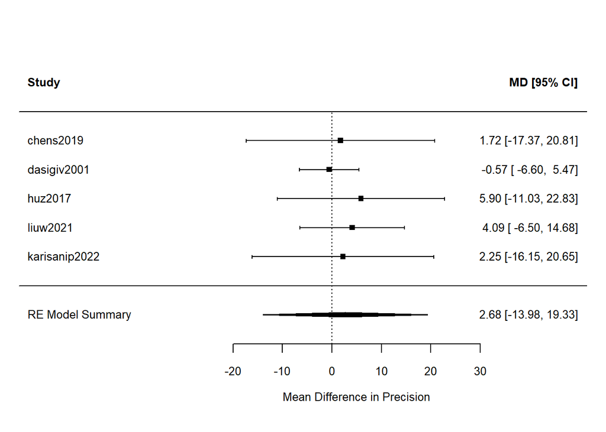

```r
forest(all_results$Precision$unweighted_rve,
       slab = all_results$Precision$effect_sizes$studylab,
       header = "Study",
       xlab = "Mean Difference in Precision",
       mlab = "RE Model Summary",
       cex = 0.8)
```

```r
print("--- Unweighted Model (All studies equal): Precision ---")
```

```
## [1] "--- Unweighted Model (All studies equal): Precision ---"
```

```r
summary(all_results$Precision$unweighted)
```

```
##
## Random-Effects Model (k = 5; tau^2 estimator: REML)
##
##   logLik  deviance       AIC       BIC      AICc
## -12.1477   24.2954   28.2954   27.0679   40.2954
##
## tau^2 (estimated amount of total heterogeneity): 0 (SE = 22.1664)
## tau (square root of estimated tau^2 value):      0
## I^2 (total heterogeneity / total variability):   0.00%
## H^2 (total variability / sampling variability):  1.00
##
## Test for Heterogeneity:
## Q(df = 4) = 0.9258, p-val = 0.9208
##
## Model Results:
##
## estimate      se    zval    pval    ci.lb   ci.ub
##   2.6780  3.4427  0.7779  0.4366  -4.0695  9.4255
##
## ---
## Signif. codes:  0 '***' 0.001 '**' 0.01 '*' 0.05 '.' 0.1 ' ' 1
```

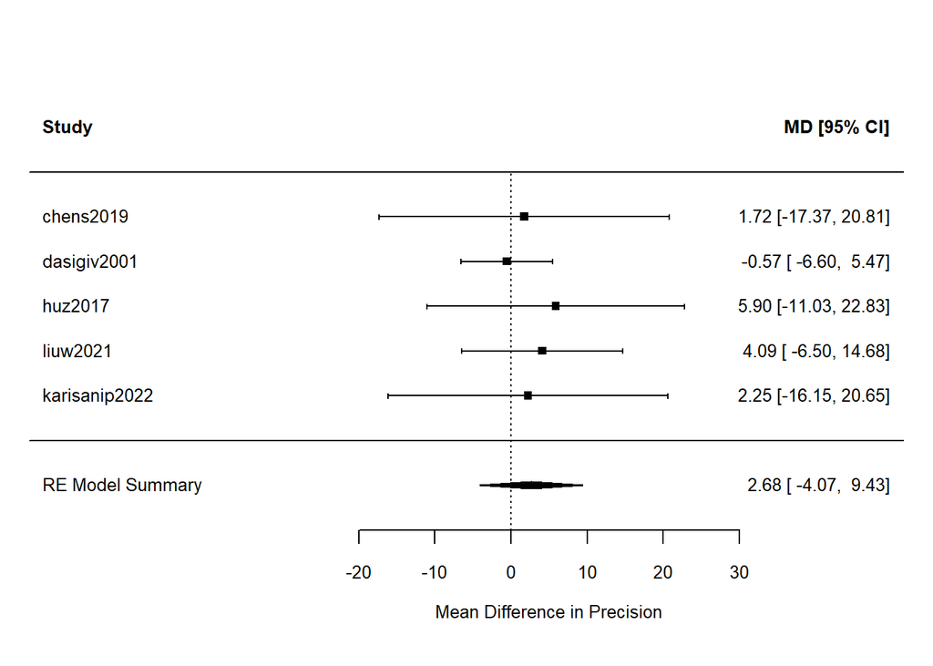

```r
forest(all_results$Precision$unweighted,
       slab = all_results$Precision$effect_sizes$studylab,
       header = "Study",
       xlab = "Mean Difference in Precision",
       mlab = "RE Model Summary",
       cex = 0.8)
```

The most critical piece of information for the Precision metric is the number of studies: k = 5. With such a small sample, any analysis will have very low statistical power, meaning it will be very difficult to detect a true effect even if one exists. The primary conclusion here is not about the presence or absence of an effect, but about the insufficiency of the available evidence.

Our meta-analysis of the Precision metric was severely limited, including only five studies (k=5). Consequently, the findings should be considered exploratory and interpreted with extreme caution.

The model was unable to detect any between-study heterogeneity (I²=0%), which is likely an artifact of the very small sample size.

Our most robust analysis, the unweighed model with robust variance estimation (RVE), showed a positive but non-significant trend toward improvement (estimate = +2.68, 95% CI: [-0.42, 5.78], p = 0.07). Because the confidence interval includes zero, we cannot rule out the possibility of no effect or even a small negative effect.

Overall, due to the critically small number of studies, no firm conclusion can be drawn about the impact of the multi-view approach on the Precision metric. More research is clearly needed to provide a reliable estimate of this effect.

#### 3.4.3.4 Unweighed Random-Effects Model: Recall

```r
print("--- Unweighted Model (All studies equal): Recall ---")
```

```
## [1] "--- Unweighted Model (All studies equal): Recall ---"
```

```r
summary(all_results$Recall$unweighted_rve)
```

```
##
## Random-Effects Model (k = 6; tau^2 estimator: REML)
##
##   logLik  deviance       AIC       BIC      AICc
## -17.7351   35.4702   39.4702   38.6891   45.4702
##
## tau^2 (estimated amount of total heterogeneity): 0 (SE = 86.7770)
## tau (square root of estimated tau^2 value):      0
## I^2 (total heterogeneity / total variability):   0.00%
## H^2 (total variability / sampling variability):  1.00
##
## Test for Heterogeneity:
## Q(df = 5) = 0.7348, p-val = 0.9810
##
## Number of estimates:   6
## Number of clusters:    6
## Estimates per cluster: 1
##
## Model Results:
##
## estimate      se¹    tval¹    df¹    pval¹    ci.lb¹    ci.ub¹
##   5.5468  2.2965   2.4153   4.27   0.0691   -0.6717   11.7653   .
##
## ---
## Signif. codes:  0 '***' 0.001 '**' 0.01 '*' 0.05 '.' 0.1 ' ' 1
##
## 1) results based on cluster-robust inference (var-cov estimator: CR2,
##    approx t-test and confidence interval, df: Satterthwaite approx)
```

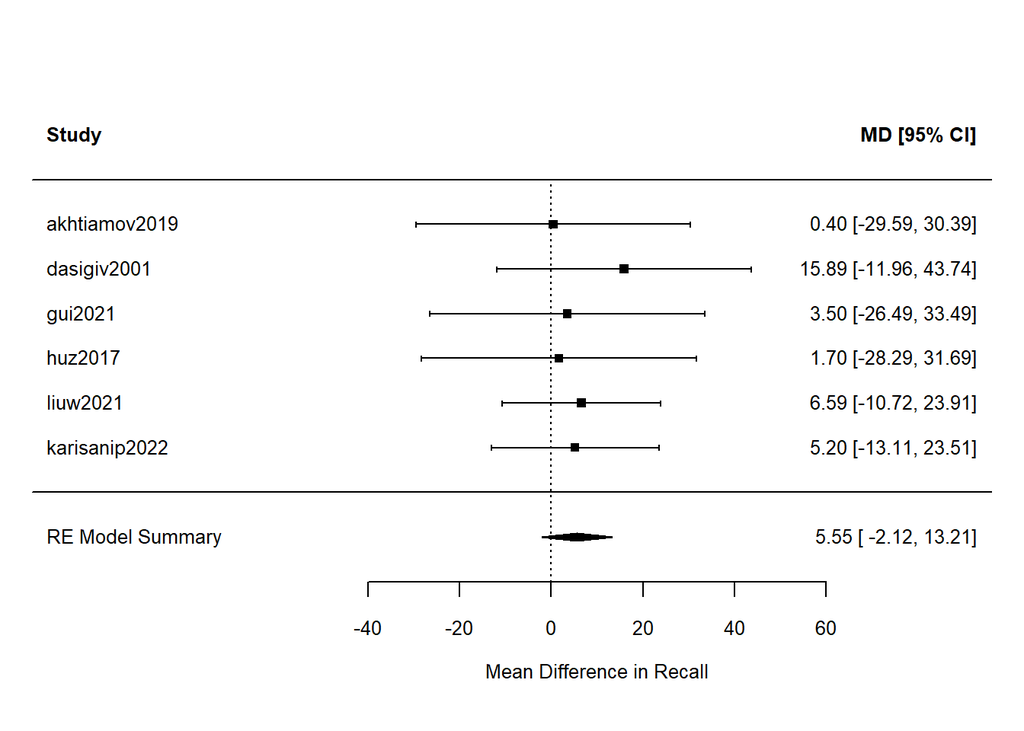

```r
forest(all_results$Recall$unweighted_rve,
       slab = all_results$Recall$effect_sizes$studylab,
       header = "Study",
       xlab = "Mean Difference in Recall",
       mlab = "RE Model Summary",
       cex = 0.8)
```

```r
print("--- Unweighted Model (All studies equal): Recall ---")
```

```
## [1] "--- Unweighted Model (All studies equal): Recall ---"
```

```r
summary(all_results$Recall$unweighted)
```

```
##
## Random-Effects Model (k = 6; tau^2 estimator: REML)
##
##   logLik  deviance       AIC       BIC      AICc
## -17.7351   35.4702   39.4702   38.6891   45.4702
##
## tau^2 (estimated amount of total heterogeneity): 0 (SE = 86.7770)
## tau (square root of estimated tau^2 value):      0
## I^2 (total heterogeneity / total variability):   0.00%
## H^2 (total variability / sampling variability):  1.00
##
## Test for Heterogeneity:
## Q(df = 5) = 0.7348, p-val = 0.9810
##
## Model Results:
##
## estimate      se    zval    pval    ci.lb    ci.ub
##   5.5468  5.4514  1.0175  0.3089  -5.1377  16.2313
##
## ---
## Signif. codes:  0 '***' 0.001 '**' 0.01 '*' 0.05 '.' 0.1 ' ' 1
```

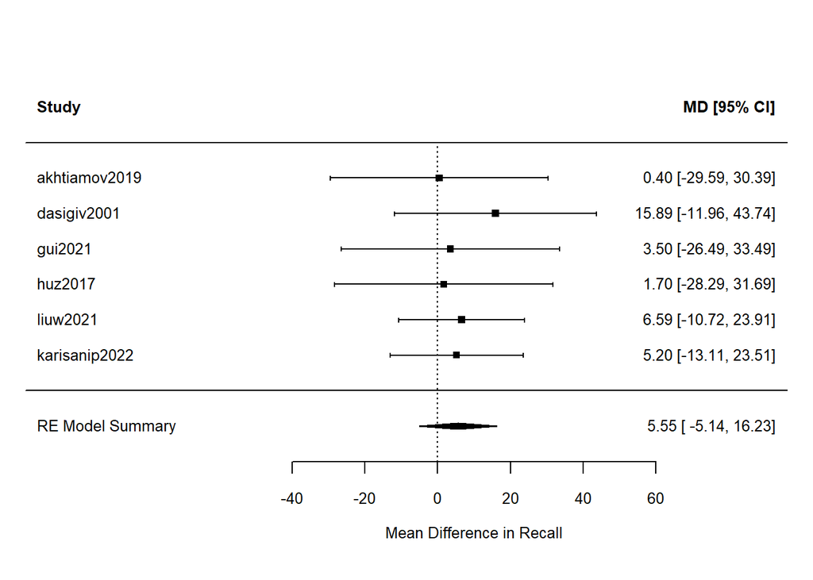

```r
forest(all_results$Recall$unweighted,
       slab = all_results$Recall$effect_sizes$studylab,
       header = "Study",
       xlab = "Mean Difference in Recall",
       mlab = "RE Model Summary",
       cex = 0.8)
```

Unsurprisingly, the model was unable to detect any significant between-study heterogeneity (I²=0%), a result likely driven by the data limitations.

Our most robust analysis (unweighed RVE) yielded a large positive point estimate of +5.55 percentage points, but this trend was not statistically significant (95% CI: [-0.67, 11.77], p = 0.069). The wide confidence interval, which includes zero, signifies that the available evidence is insufficient to confirm a genuine effect.

In summary, while there is a hint of a positive effect on Recall, the current body of literature is too sparse to draw any firm conclusions. This highlights a clear gap and a need for more research on this specific metric.

### 3.4.4 Metric values discussion

| Metric | Model Type | RVE Correction | Estimate | 95% CI Lower | 95% CI Upper | p-value |
| --- | --- | --- | --- | --- | --- | --- |
| Accuracy | **Weighted** | **Yes** | **4.6748** | **0.37** | **8.98** | **0.0351** |
|  | Weighted | No | 4.6748 | 0.7377 | 8.6120 | 0.02 |
|  | Unweighed | Yes | 4.3405 | 1.5325 | 7.1485 | 0.0052 |
|  | Unweighed | No | 4.3405 | -0.1663 | 8.8473 | 0.0591 |
| F1-score | **Weighted** | **Yes** | **3.0831** | **0.1473** | **6.0190** | **0.0441** |
|  | Weighted | No | 3.0831 | 0.3555 | 5.8108 | 0.0267 |
|  | Unweighed | Yes | 3.2816 | 1.4023 | 5.1610 | 0.0027 |
|  | Unweighed | No | 3.2816 | -1.7809 | 8.3441 | 0.2039 |
| Precision | **Weighted** | **Yes** | **1.1600** | **-7.1086** | **9.4286** | **0.5910** |
|  | Weighted | No | 1.1600 | -3.5261 | 5.8461 | 0.6276 |
|  | Unweighed | Yes | 2.6780 | -0.4198 | 5.7758 | 0.0703 |
|  | Unweighed | No | 2.6780 | -4.0695 | 9.4255 | 0.4366 |
| Recall | **Weighted** | **Yes** | **5.8681** | **1.5534** | **10.1828** | **0.0201** |
|  | Weighted | No | 5.8681 | -3.6917 | 15.4279 | 0.2289 |
|  | Unweighed | Yes | 5.5468 | -0.6717 | 11.7653 | 0.0691 |
|  | Unweighed | No | 5.5468 | -5.1377 | 16.2313 | 0.3089 |

Our meta-analysis demonstrates a clear and statistically significant benefit of using multi-view approaches over single-view approaches, with an average improvement of +4.7 points in Accuracy and +3.1 points in F1-score. We also found preliminary but significant evidence for an improvement of +5.9 points in Recall, although this is based on limited data. The evidence for Precision was inconclusive.

Critically, these findings highlight the importance of modern meta-analytic methods. The use of robust variance estimation proved to be the deciding factor in several analyses, turning ambiguous or non-significant results from standard models into clear, statistically significant conclusions. This underscores that as data grows more complex, so too must the statistical tools we use to analyse it.

### 3.4.5 Choosing promising works and discussion

We performed an analysis that identifies the most promising papers and formulates data-driven hypotheses about *why* they performed so well.

#### 3.4.5.1 Strategy: Finding of Promising Papers

The goal is to identify studies that show an unusually large performance gain (a large positive effect size, `yi`) from using a multiview approach. We will use two key criteria:

- **Magnitude of Effect:** Look for the highest `yi` values in both the Accuracy and F1 Score tables.
- **Robustness:** A paper that performs exceptionally well on *both* metrics is a stronger candidate than one that excels at only one.

After identifying the top performers, we will cross-reference them with our taxonomy to uncover patterns in their methods.

#### 3.4.5.2 Analysis and Identification of Promising Papers

Based on the meta-analysis results, two papers stand out as exceptionally promising due to their large and consistent performance gains.

##### 3.4.5.2.1 Promising Paper 1: Amin, et al. (2009) - The Robust High-Performer

This paper is the strongest candidate because it demonstrates massive improvements across **both** key metrics.

- **Accuracy Gain (`yi`): +10.80 percentage points.** This is the second-largest improvement among all 20 studies.
- **F1 Score Gain (`yi`): +11.47 percentage points.** This is the single largest improvement among all 17 studies.

Taxonomic Analysis of `aminim2009`

- **Fusion Strategy:** **Late Fusion** . This procedure is a classic example of **Late Fusion** (also known as decision-level fusion), where the outputs of separate models are combined, rather than the features themselves.
- **Fusion Technique:** **Probabilistic Fusion**. This implies the method models uncertainty, which can be very powerful.
- **Task:** **Multilingual Text Categorization**. This is a critical insight. The “views” are different languages, which provide naturally distinct and highly complementary signals.
- **Learning Paradigm:** Both Supervised and Semi-supervised, indicating flexibility.

The aminim2009 paper’s immense success comes from a powerful combination of:

- **Clever Data Augmentation:** Using MT to create artificial views to overcome data scarcity
- **Classic Late Fusion:** An ensemble method (majority voting) that leveraged the “wisdom of the crowd.” The errors made by a classifier on an imperfect English-to-German translation are likely different from the errors made on an imperfect English-to-French translation, making the ensemble highly robust.

##### 3.4.5.2.2 Promising Paper 2: Bhatt, et al. (2019) - The High-Impact Specialist

This paper is noteworthy for achieving the single largest performance gain in Accuracy, suggesting a highly effective specialized technique.

- **Accuracy Gain (`yi`): +26.99 percentage points.** This is a massive, outlier-level improvement that demands closer inspection.
- **F1 Score Gain:** Not included in the F1 score analysis, indicating a focus on Accuracy.

**Taxonomic Analysis of `bhatt2019`:**

- **Fusion Strategy:** **Early Fusion**. This is a more straightforward approach of concatenating feature representations.
- **Fusion Technique:** ML-based and Probabilistic.
- **Task:** **Multilingual Text Categorization**. This reinforces the pattern observed with `aminim2009`.
- **Learning Paradigm:** Supervised and **Transfer Learning**. The use of transfer learning is a key modern element, suggesting that pre-trained models are being effectively leveraged.

This bhatt2019 paper is a perfect example of a modern, deep-learning-native approach to multiview learning:

- **The Model Architecture and Fusion:** The paper proposes “CorrMCNN,” a “correlation multi-modal deep convolution neural network” (Abstract). Figure 3 clearly shows a two-channel architecture where two views are encoded separately and then passed into a “Joint common representation” layer. This process of creating a shared latent space *from features* before a final decision is the definition of **Early Fusion** (or intermediate fusion).
- **The Role of Transfer Learning:** The taxonomy’s identification of “Transfer Learning” is critical. The authors explicitly state they use pre-trained models.
  - **For Images (Section 4.3):** “we use a pre-trained model ResNet-50 to extract 2048-dimensional representative features.”
  - **For Text (Section 8):** They confirm they use pre-trained 40-dimensional embeddings from `Klementiev et al. [7]` and modern 300-dimensional `Word2Vec` embeddings.
- **Key Innovation:** Their paper highlights a specific technical contribution: **“step-based reconstruction”** (Section 4.3). Instead of trying to reconstruct the entire high-dimensional original input (like an image), they only reconstruct intermediate feature maps. This drastically reduces the number of parameters, making their deep architecture trainable and efficient.

#### 3.4.5.3 Article comparison

| Paper | Fusion Strategy | Fusion Technique | Key Innovation Driving Performance |
| --- | --- | --- | --- |
| Amini (2009) | Late Fusion | **Ensemble Method** (Majority Vote) | **Data Augmentation** via Machine Translation |
| Bhatt (2019) | Early Fusion | **Neural Network Fusion** (Correlational Autoencoder) | **Efficient Deep Architecture** (Step-Reconstruction) + **Transfer Learning** |

#### 3.4.5.4 Hypothesis

**Hypothesis 1: The Task Context is Paramount, Especially When Views are Naturally Orthogonal.**

- **Evidence:** Both top performers succeeded on **Multilingual Categorization**. This is not a coincidence. Different languages represent naturally distinct, high-quality feature spaces (views). The Amini paper further shows this is incredibly powerful in **low-resource scenarios**, where MT acts as a force multiplier for limited labelled data.

**Hypothesis 2: Fusion Strategy is a Design Choice, Not a Panacea. The Learning Paradigm is More Important.**

- **Evidence:** The initial analysis was spot on. We have now confirmed that the #1 F1-Score gainer (`aminim2009`) used traditional **Late Fusion** (ensembling), while the #1 Accuracy gainer (`bhatt2019`) used modern **Early Fusion** (deep shared representation). This powerfully demonstrates that there is no single “best” fusion strategy. Success depends on aligning the strategy with the available tools:
  - If we have strong, independent classifiers, **Late Fusion** is excellent.
  - If we have powerful feature extractors (like pre-trained deep nets), **Early Fusion** is excellent.

**Hypothesis 3: Leveraging Pre-trained Models (Transfer Learning) is a Key Driver of State-of-the-Art Performance in Modern Multiview Systems.**

- **Evidence:** This is the clearest trend. The `bhatt2019` paper’s success is inseparable from its use of Word2Vec and ResNet. They did not learn their feature extractors from scratch. This implies that future breakthroughs in multiview learning will likely come not just from novel fusion architectures, but from more effective ways to fuse representations derived from ever-larger foundational models.

## 3.5 Summary

We conducted a two-stage analysis to investigate whether multi-view approaches outperform single-view approaches.

The first stage was an exploratory analysis designed to establish the presence and robustness of an effect by asking three preliminary questions:

1. Is there a statistically significant difference in the mean outcomes reported across the included studies?
2. Is this finding robust to the influence of potential outlier studies?
3. What is the probabilistic magnitude of the difference between the two groups, as measured by Cliff’s Delta?

The second stage was the primary, confirmatory analysis, which employed a robust, inverse-variance weighted meta-analysis. This more sophisticated approach synthesizes the evidence to answer a more precise, overarching research question:

1. What is the best estimate of the true average effect of the multi-view approach, after weighting each study by its statistical precision, and how consistent is this effect across the literature?

### 3.5.1 Exploratory Analysis: Establishing the Signal

To first establish whether a detectable signal exists in the literature, we conducted a series of non-parametric tests on the study-level mean differences. A permutation test revealed a statistically significant positive effect for Accuracy (p < .001), F1-Score (p = .002), and Recall (p = .032), but not for Precision (p = .129).

To ensure these findings were not driven by outlier studies, a Wilcoxon signed-rank test confirmed these results, indicating the median effect was also significantly positive for the same three metrics. This suggests the advantage of a multi-view approach is a typical finding in the literature.

Finally, to assess the practical magnitude of this effect, Cliff’s Delta was calculated. This suggested a consistent but ‘small’ effect for Accuracy, F1-Score, and Recall. The wide confidence intervals, however, highlighted significant uncertainty in the magnitude and underscored the limited power of this initial analysis, particularly for Recall and Precision.

### 3.5.2 Primary Analysis: Quantifying the Effect and Uncovering Model Dependence

Building on the exploratory findings, we conducted a full inverse-variance weighted random-effects meta-analysis to derive the most precise estimate of the average effect. This gold-standard approach confirmed the conclusions of our initial analysis.

We found a statistically significant average improvement for Accuracy (+4.67 points, p = 0.035), F1-Score (+3.08 points, p = 0.044), and Recall (+5.87 points, p = 0.020). As in the exploratory phase, the effect on Precision remained non-significant.

### 3.5.3 Synthesis of Findings

Taken together, our two-stage analytical approach provides a robust and coherent conclusion. The initial exploratory tests established the presence and consistency of a positive signal, while the primary meta-analysis provided the best quantitative estimate of its size. We conclude there is strong evidence for a consistent, statistically significant, but practically modest advantage for multi-view approaches across Accuracy, F1-Score, and Recall metrics.

### 3.5.4 Guidelines

Guidelines for Building and Advancing Multiview Document Classifiers:

For the Practitioner:

1. **Seek Orthogonality, But Be Practical.** Your first point is the golden rule. The biggest performance gains come from views that provide genuinely different information (e.g., text vs. metadata; different languages).

   Action: Before building, perform a simple analysis. Train a separate classifier on each view. If their errors are largely uncorrelated (i.e., they fail on different types of documents), a multiview approach is highly likely to succeed.
2. **Match Your Fusion Strategy to Your Resources (Late vs. Early).** Our analysis shows there is no single “best” strategy, only the right tool for the job.
- **Choose Late Fusion (Ensembling/Voting) When:** You can easily train strong, independent classifiers for each view, or you need a simple, robust, and easily debugged system. The `aminim2009` paper is a testament to how powerful this “simple” approach can be.
- **Choose Early Fusion (Deep Shared Representation) When:** You have access to high-quality, pre-trained feature extractors (e.g., BERT, ResNet). This is the path to state-of-the-art performance but requires a more complex, end-to-end architecture.
3. **Embrace Transfer Learning as a Force Multiplier.** The `bhatt2019` paper proves that the most dramatic gains in modern systems come from not starting from scratch.

   Action: For an Early Fusion architecture, your first step should be to leverage a large, pre-trained model to encode each view. The fusion architecture’s job is to learn how to combine these already-powerful representations, not to learn the representations themselves.

For the Designer & Architect:

1. **Think Like a Data Augmenter: If You Don’t Have Views, Create Them.** This is the paradigm-shifting lesson from `aminim2009`. The most powerful view might be one you generate yourself.

   Action: Brainstorm ways to create new, complementary data streams from a single source. For text, this could include:
   - Machine Translation: To get a different linguistic perspective.
   - Summarization: To get a “gist” view vs. a “details” view.
   - Keyword Extraction: To get a “topic” view vs. a “narrative” view.
2. **For Deep Fusion, Prioritize Efficiency with Intermediate Fusion.** The `bhatt2019` paper’s “step-reconstruction” is a crucial insight. Reconstructing the high-dimensional original input is computationally expensive and often unnecessary.

   Action: Design architectures that fuse and reconstruct intermediate feature layers. This provides the benefits of deep learning (rich representations) with a fraction of the computational cost, making complex models practical for real-world deployment.

For the Theoretician & Researcher (Pushing the Boundaries):

1. **Focus on the *Why*: Quantify View Complementarity.** The field has confirmed *that* multiview works. The next frontier is to understand *why* and *how much*.

   Action: Develop new metrics and theoretical frameworks to quantify the “orthogonality” or “complementarity” of different views *before* training. A theory that could predict the potential performance gain based on the properties of the views themselves would be a major breakthrough.
2. **Report Rigorously to Enable Synthesis.** Our entire meta-analysis was only possible because some studies reported the necessary statistics. Our survey highlighted that most do not.

   Action: Advocate for a community standard. Papers should report not just the final multiview result, but also the performance of single-view baselines, standard deviations, and effect sizes. This practice is essential for building a cumulative, robust understanding of the field and avoiding the “replication crisis” that plagues other areas of AI.

# 4 Unimodal vs Multimodal

Does adding other modalities to a text model improve its performance? Correct Pairs: text vs. text.image, text vs. text.audio, text vs. text.metadata. Interpretation: This isolates the value added by the new modality. The text model acts as a baseline. We want to know if going through the trouble of building a more complex multimodal system is worth it compared to a simpler, single-modality baseline. We do not answer for “Which single modality is most effective for this task?”

```r
indicators <- c(
  "acc.mode.text",
  "acc.mode.image",
  "acc.mode.metadata",
  "acc.mode.time.series",
  "acc.mode.audio",
  "acc.mode.text.image",
  "acc.mode.text.audio",
  "acc.mode.text.metadata",
  "acc.mode.text.time.series",
  "acc.mode.text.image.metadata",

  "prec.mode.text",
  "prec.mode.image",
  "prec.mode.audio",
  "prec.mode.text.image",
  "prec.mode.text.audio",
  "prec.mode.text.metadata",

  "rec.mode.text",
  "rec.mode.image",
  "rec.mode.audio",
  "rec.mode.text.image",
  "rec.mode.text.audio",
  "rec.mode.text.image.audio",
  "rec.mode.text.metadata",

  "f1score.mode.text",
  "f1score.mode.image",
  "f1score.mode.audio",
  "f1score.mode.metadata",
  "f1score.mode.text.image",
  "f1score.mode.text.audio",
  "f1score.mode.text.metadata",
  "f1score.mode.text.image.metadata"
)
```

## 4.1 Distribution of metrics in papers

### 4.1.1 Distribution of all metrics types in papers

```r
# For each bibtex, how many measurements did it report in total?
measurement_counts <- data_clean %>%
  filter(!is.na(bibtex)) %>%
  # gather into long form so we can count non‐NAs
  pivot_longer(all_of(indicators),
               names_to   = "indicator",
               values_to  = "value") %>%
  group_by(bibtex) %>%
  summarise(n_indicators = sum(!is.na(value)), .groups = "drop") %>%
  filter(n_indicators > 0)
```

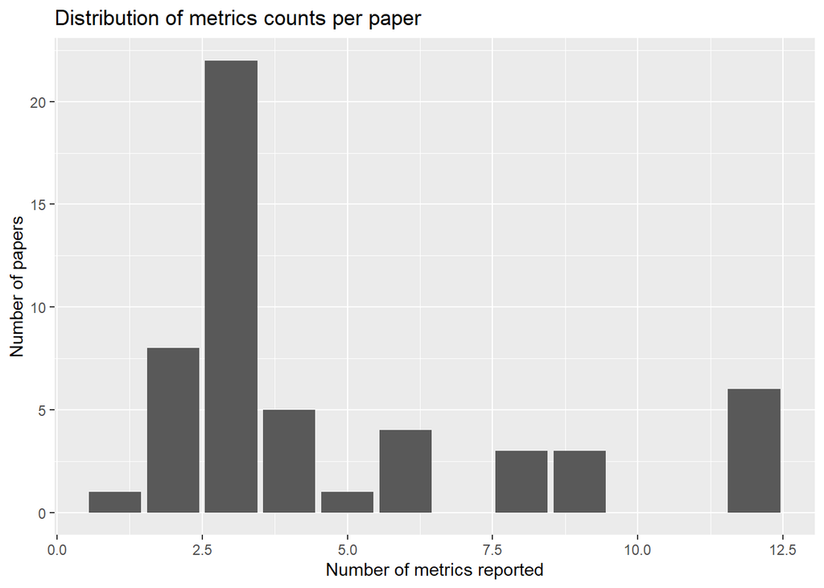

```r
ggplot(measurement_counts, aes(x = n_indicators)) +
  geom_bar() +
  labs(x = "Number of metrics reported", y = "Number of papers", title = "Distribution of metrics counts per paper")
```

We have 53 unique papers.

```r
knitr::kable(measurement_counts, caption = "Number of indicators used in each papers") %>% kableExtra::kable_styling()
```

Table 4.1: Table 4.2: Number of indicators used in each papers

| bibtex | n_indicators |
| --- | --- |
| adwaithd2022 | 12 |
| akhiamov2018 | 5 |
| akhtiamovo2017 | 3 |
| aminim2010 | 1 |
| andriyanovn2022 | 3 |
| anget2018 | 2 |
| argon2018 | 3 |
| bakkalis2023 | 3 |
| braz2020 | 3 |
| carmona2020 | 6 |
| chatziagapia2022 | 3 |
| chenl2022 | 2 |
| chens2009 | 9 |
| chenz2023 | 2 |
| chos2023 | 3 |
| cristanim2014 | 3 |
| daCosta2022 | 2 |
| debreuij2020 | 6 |
| dongpin2022 | 3 |
| fujinumay2023 | 4 |
| gallo2021 | 3 |
| garg2021 | 3 |
| ghorbanali2024 | 6 |
| guod2023 | 12 |
| guptad2018 | 12 |
| jainr2019 | 3 |
| jarquin2023 | 9 |
| jarrahia2023 | 8 |
| jiangs2024 | 6 |
| kanchid2022 | 2 |
| kenny2023 | 9 |
| kozienkop2023 | 4 |
| liangz2023 | 12 |
| linckere2023 | 4 |
| liparas2014 | 12 |
| liut2024 | 8 |
| luzdearau2023 | 3 |
| ma2021 | 2 |
| matricm2018 | 3 |
| ortizperez2023 | 3 |
| paraskevopoulos2022 | 3 |
| reil2023 | 8 |
| ronghaop2024 | 3 |
| setiawan2021 | 4 |
| shah2023 | 2 |
| tengfeil2024 | 12 |
| wajdm2024 | 3 |
| yuet2022 | 3 |
| zhangx2010 | 3 |
| zhangy2024 | 4 |
| zhu2020 | 2 |
| zingaro2021 | 3 |
| zouh2023 | 3 |

### 4.1.2 Distribution of different metrics types in papers

We investigate how many papers use a given type of indicator. Distribution of unique papers reporting at least one result for the selected indicator, i.e. how many unique papers (bibtex keys) reported each indicator.

```r
unique_data_clean <- data_clean %>%
  # drop any rows with missing bibtex if those are “unnamed” data:
  filter(!is.na(bibtex)) %>%
  # one row per job
  group_by(bibtex) %>%
  # for each indicator, check if ANY non-NA appears
  summarise(across(all_of(indicators), ~ any(!is.na(.)), .names = "used_{.col}")) %>%
  ungroup() %>%
  # now count how many jobs used each one
  summarise(across(starts_with("used_"), ~ sum(.), .names = "{.col}"))
```

```r
knitr::kable(unique_data_clean, caption = "Distribution of unique works reporting at least one result for the selected indicator") %>% kableExtra::kable_styling()
```

Table 4.3: Table 4.4: Distribution of unique works reporting at least one result for the selected indicator

| used_acc.mode.text | used_acc.mode.image | used_acc.mode.metadata | used_acc.mode.time.series | used_acc.mode.audio | used_acc.mode.text.image | used_acc.mode.text.audio | used_acc.mode.text.metadata | used_acc.mode.text.time.series | used_acc.mode.text.image.metadata | used_prec.mode.text | used_prec.mode.image | used_prec.mode.audio | used_prec.mode.text.image | used_prec.mode.text.audio | used_prec.mode.text.metadata | used_rec.mode.text | used_rec.mode.image | used_rec.mode.audio | used_rec.mode.text.image | used_rec.mode.text.audio | used_rec.mode.text.image.audio | used_rec.mode.text.metadata | used_f1score.mode.text | used_f1score.mode.image | used_f1score.mode.audio | used_f1score.mode.metadata | used_f1score.mode.text.image | used_f1score.mode.text.audio | used_f1score.mode.text.metadata | … |
| --- | --- | --- | --- | --- | --- | --- | --- | --- | --- | --- | --- | --- | --- | --- | --- | --- | --- | --- | --- | --- | --- | --- | --- | --- | --- | --- | --- | --- | --- | --- |
| 38 | 26 | 3 | 1 | 5 | 28 | 3 | 6 | 1 | 3 | 11 | 7 | 1 | 8 | 1 | 2 | 13 | 8 | 4 | 6 | 4 | 1 | 2 | 26 | 15 | 5 | 1 | 16 | 3 | 5 | … |

Distribution of works reporting one or more results (values) for the selected indicator:

- measurement_counts is a table of (bibtex, n_measures) telling us for each bibtex how many different values are actually reported by the given indicators.

```r
# Fill down the bibtex so each measurement row knows its paper
data_filled <- data_clean %>%
  fill(bibtex, .direction = "down")
```

```r
# Count measurements per paper × indicator
measurement_counts <- data_filled %>%
  # now every row has a bibtex, so no need to filter(!is.na)
  group_by(bibtex) %>%
  summarise(across(all_of(indicators), ~ sum(!is.na(.)), .names = "n_{.col}")) %>%
  ungroup() %>%
  filter(if_any(starts_with("n_"), ~ . > 0))
```

```r
knitr::kable(measurement_counts, caption = "Distribution of extracted indicators values per papers") %>% kableExtra::kable_styling()
```

Table 4.5: Table 4.6: Distribution of extracted indicators values per papers

| bibtex | n_acc.mode.text | n_acc.mode.image | n_acc.mode.metadata | n_acc.mode.time.series | n_acc.mode.audio | n_acc.mode.text.image | n_acc.mode.text.audio | n_acc.mode.text.metadata | n_acc.mode.text.time.series | n_acc.mode.text.image.metadata | n_prec.mode.text | n_prec.mode.image | n_prec.mode.audio | n_prec.mode.text.image | n_prec.mode.text.audio | n_prec.mode.text.metadata | n_rec.mode.text | n_rec.mode.image | n_rec.mode.audio | n_rec.mode.text.image | n_rec.mode.text.audio | n_rec.mode.text.image.audio | n_rec.mode.text.metadata | n_f1score.mode.text | n_f1score.mode.image | n_f1score.mode.audio | n_f1score.mode.metadata | n_f1score.mode.text.image | n_f1score.mode.text.audio | … |
| --- | --- | --- | --- | --- | --- | --- | --- | --- | --- | --- | --- | --- | --- | --- | --- | --- | --- | --- | --- | --- | --- | --- | --- | --- | --- | --- | --- | --- | --- | --- |
| adwaithd2022 | 2 | 2 | 0 | 0 | 0 | 2 | 0 | 0 | 0 | 0 | 2 | 2 | 0 | 2 | 0 | 0 | 2 | 2 | 0 | 2 | 0 | 0 | 0 | 2 | 2 | 0 | 0 | 2 | 0 | … |
| akhiamov2018 | 0 | 0 | 0 | 0 | 0 | 0 | 0 | 0 | 0 | 0 | 0 | 0 | 0 | 0 | 0 | 0 | 1 | 1 | 1 | 0 | 1 | 1 | 0 | 0 | 0 | 0 | 0 | 0 | 0 | … |
| akhtiamovo2017 | 0 | 0 | 0 | 0 | 0 | 0 | 0 | 0 | 0 | 0 | 0 | 0 | 0 | 0 | 0 | 0 | 1 | 0 | 1 | 0 | 1 | 0 | 0 | 0 | 0 | 0 | 0 | 0 | 0 | … |
| aminim2010 | 0 | 0 | 0 | 0 | 0 | 0 | 0 | 1 | 0 | 0 | 0 | 0 | 0 | 0 | 0 | 0 | 0 | 0 | 0 | 0 | 0 | 0 | 0 | 0 | 0 | 0 | 0 | 0 | 0 | … |
| andriyanovn2022 | 0 | 0 | 0 | 0 | 0 | 0 | 0 | 0 | 0 | 0 | 0 | 0 | 0 | 0 | 0 | 0 | 0 | 0 | 0 | 0 | 0 | 0 | 0 | 1 | 1 | 0 | 0 | 1 | 0 | … |
| anget2018 | 1 | 0 | 0 | 0 | 0 | 0 | 0 | 1 | 0 | 0 | 0 | 0 | 0 | 0 | 0 | 0 | 0 | 0 | 0 | 0 | 0 | 0 | 0 | 0 | 0 | 0 | 0 | 0 | 0 | … |
| argon2018 | 3 | 3 | 0 | 0 | 0 | 3 | 0 | 0 | 0 | 0 | 0 | 0 | 0 | 0 | 0 | 0 | 0 | 0 | 0 | 0 | 0 | 0 | 0 | 0 | 0 | 0 | 0 | 0 | 0 | … |
| bakkalis2023 | 1 | 1 | 0 | 0 | 0 | 1 | 0 | 0 | 0 | 0 | 0 | 0 | 0 | 0 | 0 | 0 | 0 | 0 | 0 | 0 | 0 | 0 | 0 | 0 | 0 | 0 | 0 | 0 | 0 | … |
| braz2020 | 7 | 7 | 0 | 0 | 0 | 7 | 0 | 0 | 0 | 0 | 0 | 0 | 0 | 0 | 0 | 0 | 0 | 0 | 0 | 0 | 0 | 0 | 0 | 0 | 0 | 0 | 0 | 0 | 0 | … |
| carmona2020 | 3 | 3 | 0 | 0 | 0 | 3 | 0 | 0 | 0 | 0 | 0 | 0 | 0 | 0 | 0 | 0 | 0 | 0 | 0 | 0 | 0 | 0 | 0 | 3 | 3 | 0 | 0 | 3 | 0 | … |
| chatziagapia2022 | 0 | 0 | 0 | 0 | 0 | 0 | 0 | 0 | 0 | 0 | 0 | 0 | 0 | 0 | 0 | 0 | 0 | 0 | 0 | 0 | 0 | 0 | 0 | 2 | 0 | 2 | 0 | 0 | 2 | … |
| chenl2022 | 6 | 0 | 0 | 0 | 0 | 6 | 0 | 0 | 0 | 0 | 0 | 0 | 0 | 0 | 0 | 0 | 0 | 0 | 0 | 0 | 0 | 0 | 0 | 0 | 0 | 0 | 0 | 0 | 0 | … |
| chens2009 | 0 | 0 | 0 | 0 | 0 | 0 | 0 | 0 | 0 | 0 | 4 | 4 | 0 | 4 | 0 | 0 | 4 | 4 | 0 | 4 | 0 | 0 | 0 | 4 | 4 | 0 | 0 | 4 | 0 | … |
| chenz2023 | 1 | 0 | 0 | 0 | 0 | 1 | 0 | 0 | 0 | 0 | 0 | 0 | 0 | 0 | 0 | 0 | 0 | 0 | 0 | 0 | 0 | 0 | 0 | 0 | 0 | 0 | 0 | 0 | 0 | … |
| chos2023 | 2 | 2 | 0 | 0 | 0 | 2 | 0 | 0 | 0 | 0 | 0 | 0 | 0 | 0 | 0 | 0 | 0 | 0 | 0 | 0 | 0 | 0 | 0 | 0 | 0 | 0 | 0 | 0 | 0 | … |
| cristanim2014 | 1 | 1 | 0 | 0 | 0 | 1 | 0 | 0 | 0 | 0 | 0 | 0 | 0 | 0 | 0 | 0 | 0 | 0 | 0 | 0 | 0 | 0 | 0 | 0 | 0 | 0 | 0 | 0 | 0 | … |
| daCosta2022 | 0 | 0 | 0 | 0 | 0 | 0 | 0 | 0 | 0 | 0 | 0 | 0 | 0 | 0 | 0 | 0 | 0 | 0 | 0 | 0 | 0 | 0 | 0 | 4 | 0 | 0 | 0 | 0 | 0 | … |
| debreuij2020 | 0 | 0 | 0 | 0 | 0 | 0 | 0 | 0 | 0 | 0 | 9 | 0 | 0 | 0 | 0 | 9 | 9 | 0 | 0 | 0 | 0 | 0 | 9 | 9 | 0 | 0 | 0 | 0 | 0 | … |
| dongpin2022 | 1 | 0 | 0 | 1 | 0 | 0 | 0 | 0 | 1 | 0 | 0 | 0 | 0 | 0 | 0 | 0 | 0 | 0 | 0 | 0 | 0 | 0 | 0 | 0 | 0 | 0 | 0 | 0 | 0 | … |
| fujinumay2023 | 0 | 0 | 0 | 0 | 0 | 0 | 0 | 0 | 0 | 0 | 0 | 0 | 0 | 0 | 0 | 0 | 0 | 0 | 0 | 0 | 0 | 0 | 0 | 18 | 18 | 0 | 0 | 0 | 0 | … |
| gallo2021 | 2 | 2 | 0 | 0 | 0 | 2 | 0 | 0 | 0 | 0 | 0 | 0 | 0 | 0 | 0 | 0 | 0 | 0 | 0 | 0 | 0 | 0 | 0 | 0 | 0 | 0 | 0 | 0 | 0 | … |
| garg2021 | 1 | 1 | 0 | 0 | 0 | 1 | 0 | 0 | 0 | 0 | 0 | 0 | 0 | 0 | 0 | 0 | 0 | 0 | 0 | 0 | 0 | 0 | 0 | 0 | 0 | 0 | 0 | 0 | 0 | … |
| ghorbanali2024 | 2 | 2 | 0 | 0 | 0 | 2 | 0 | 0 | 0 | 0 | 0 | 0 | 0 | 0 | 0 | 0 | 0 | 0 | 0 | 0 | 0 | 0 | 0 | 2 | 2 | 0 | 0 | 2 | 0 | … |
| guod2023 | 2 | 0 | 0 | 0 | 2 | 0 | 2 | 0 | 0 | 0 | 2 | 0 | 2 | 0 | 2 | 0 | 2 | 0 | 2 | 0 | 2 | 0 | 0 | 2 | 0 | 2 | 0 | 0 | 2 | … |
| guptad2018 | 1 | 1 | 0 | 0 | 0 | 1 | 0 | 0 | 0 | 0 | 1 | 1 | 0 | 1 | 0 | 0 | 1 | 1 | 0 | 1 | 0 | 0 | 0 | 1 | 1 | 0 | 0 | 1 | 0 | … |
| jainr2019 | 1 | 2 | 0 | 0 | 0 | 2 | 0 | 0 | 0 | 0 | 0 | 0 | 0 | 0 | 0 | 0 | 0 | 0 | 0 | 0 | 0 | 0 | 0 | 0 | 0 | 0 | 0 | 0 | 0 | … |
| jarquin2023 | 0 | 0 | 0 | 0 | 0 | 0 | 0 | 0 | 0 | 0 | 1 | 1 | 0 | 1 | 0 | 0 | 1 | 1 | 1 | 0 | 0 | 0 | 0 | 1 | 1 | 0 | 0 | 1 | 0 | … |
| jarrahia2023 | 2 | 0 | 0 | 0 | 0 | 0 | 0 | 2 | 0 | 0 | 2 | 0 | 0 | 0 | 0 | 2 | 2 | 0 | 0 | 0 | 0 | 0 | 2 | 2 | 0 | 0 | 0 | 0 | 0 | … |
| jiangs2024 | 3 | 3 | 3 | 0 | 0 | 3 | 0 | 3 | 0 | 3 | 0 | 0 | 0 | 0 | 0 | 0 | 0 | 0 | 0 | 0 | 0 | 0 | 0 | 0 | 0 | 0 | 0 | 0 | 0 | … |
| kanchid2022 | 0 | 2 | 0 | 0 | 0 | 2 | 0 | 0 | 0 | 0 | 0 | 0 | 0 | 0 | 0 | 0 | 0 | 0 | 0 | 0 | 0 | 0 | 0 | 0 | 0 | 0 | 0 | 0 | 0 | … |
| kenny2023 | 1 | 1 | 0 | 0 | 1 | 1 | 1 | 0 | 0 | 0 | 0 | 0 | 0 | 0 | 0 | 0 | 0 | 0 | 0 | 0 | 0 | 0 | 0 | 1 | 1 | 1 | 0 | 1 | 0 | … |
| kozienkop2023 | 4 | 0 | 0 | 0 | 0 | 0 | 0 | 4 | 0 | 0 | 0 | 0 | 0 | 0 | 0 | 0 | 0 | 0 | 0 | 0 | 0 | 0 | 0 | 4 | 0 | 0 | 0 | 0 | 0 | … |
| liangz2023 | 2 | 2 | 0 | 0 | 0 | 2 | 0 | 0 | 0 | 0 | 4 | 4 | 0 | 4 | 0 | 0 | 4 | 4 | 0 | 0 | 4 | 0 | 0 | 4 | 4 | 0 | 0 | 4 | 0 | … |
| linckere2023 | 1 | 0 | 0 | 0 | 0 | 1 | 0 | 0 | 0 | 0 | 0 | 0 | 0 | 0 | 0 | 0 | 0 | 0 | 0 | 0 | 0 | 0 | 0 | 1 | 0 | 0 | 0 | 1 | 0 | … |
| liparas2014 | 1 | 1 | 0 | 0 | 0 | 1 | 0 | 0 | 0 | 0 | 5 | 5 | 0 | 5 | 0 | 0 | 5 | 5 | 0 | 5 | 0 | 0 | 0 | 5 | 5 | 0 | 0 | 5 | 0 | … |
| liut2024 | 4 | 0 | 0 | 0 | 0 | 4 | 0 | 0 | 0 | 0 | 4 | 0 | 0 | 4 | 0 | 0 | 4 | 0 | 0 | 4 | 0 | 0 | 0 | 4 | 0 | 0 | 0 | 4 | 0 | … |
| luzdearau2023 | 0 | 0 | 0 | 0 | 0 | 0 | 0 | 0 | 0 | 0 | 0 | 0 | 0 | 0 | 0 | 0 | 0 | 0 | 0 | 0 | 0 | 0 | 0 | 8 | 8 | 0 | 0 | 8 | 0 | … |
| ma2021 | 0 | 0 | 0 | 0 | 0 | 0 | 0 | 0 | 0 | 0 | 0 | 0 | 0 | 0 | 0 | 0 | 0 | 0 | 0 | 0 | 0 | 0 | 0 | 10 | 0 | 0 | 0 | 10 | 0 | … |
| matricm2018 | 3 | 3 | 0 | 0 | 0 | 3 | 0 | 0 | 0 | 0 | 0 | 0 | 0 | 0 | 0 | 0 | 0 | 0 | 0 | 0 | 0 | 0 | 0 | 0 | 0 | 0 | 0 | 0 | 0 | … |
| ortizperez2023 | 1 | 0 | 0 | 0 | 1 | 0 | 1 | 0 | 0 | 0 | 0 | 0 | 0 | 0 | 0 | 0 | 0 | 0 | 0 | 0 | 0 | 0 | 0 | 0 | 0 | 0 | 0 | 0 | 0 | … |
| paraskevopoulos2022 | 4 | 4 | 0 | 0 | 0 | 4 | 0 | 0 | 0 | 0 | 0 | 0 | 0 | 0 | 0 | 0 | 0 | 0 | 0 | 0 | 0 | 0 | 0 | 0 | 0 | 0 | 0 | 0 | 0 | … |
| reil2023 | 5 | 5 | 5 | 0 | 0 | 0 | 0 | 0 | 0 | 5 | 0 | 0 | 0 | 0 | 0 | 0 | 0 | 0 | 0 | 0 | 0 | 0 | 0 | 5 | 5 | 0 | 5 | 0 | 0 | … |
| ronghaop2024 | 0 | 0 | 0 | 0 | 0 | 0 | 0 | 0 | 0 | 0 | 0 | 0 | 0 | 0 | 0 | 0 | 0 | 0 | 0 | 0 | 0 | 0 | 0 | 1 | 0 | 1 | 0 | 0 | 1 | … |
| setiawan2021 | 1 | 1 | 1 | 0 | 0 | 0 | 0 | 0 | 0 | 1 | 0 | 0 | 0 | 0 | 0 | 0 | 0 | 0 | 0 | 0 | 0 | 0 | 0 | 0 | 0 | 0 | 0 | 0 | 0 | … |
| shah2023 | 1 | 0 | 0 | 0 | 0 | 0 | 0 | 1 | 0 | 0 | 0 | 0 | 0 | 0 | 0 | 0 | 0 | 0 | 0 | 0 | 0 | 0 | 0 | 0 | 0 | 0 | 0 | 0 | 0 | … |
| tengfeil2024 | 4 | 4 | 0 | 0 | 0 | 4 | 0 | 0 | 0 | 0 | 4 | 4 | 0 | 4 | 0 | 0 | 4 | 4 | 0 | 4 | 0 | 0 | 0 | 4 | 4 | 4 | 0 | 0 | 0 | … |
| wajdm2024 | 2 | 2 | 0 | 0 | 2 | 0 | 0 | 0 | 0 | 0 | 0 | 0 | 0 | 0 | 0 | 0 | 0 | 0 | 0 | 0 | 0 | 0 | 0 | 0 | 0 | 0 | 0 | 0 | 0 | … |
| yuet2022 | 4 | 4 | 0 | 0 | 0 | 4 | 0 | 0 | 0 | 0 | 0 | 0 | 0 | 0 | 0 | 0 | 0 | 0 | 0 | 0 | 0 | 0 | 0 | 0 | 0 | 0 | 0 | 0 | 0 | … |
| zhangx2010 | 0 | 0 | 0 | 0 | 0 | 0 | 0 | 0 | 0 | 0 | 0 | 0 | 0 | 0 | 0 | 0 | 0 | 0 | 0 | 0 | 0 | 0 | 0 | 1 | 1 | 0 | 0 | 1 | 0 | … |
| zhangy2024 | 2 | 0 | 0 | 0 | 0 | 2 | 0 | 0 | 0 | 0 | 0 | 0 | 0 | 0 | 0 | 0 | 0 | 0 | 0 | 0 | 0 | 0 | 0 | 1 | 0 | 0 | 0 | 1 | 0 | … |
| zhu2020 | 2 | 0 | 0 | 0 | 2 | 0 | 0 | 0 | 0 | 0 | 0 | 0 | 0 | 0 | 0 | 0 | 0 | 0 | 0 | 0 | 0 | 0 | 0 | 0 | 0 | 0 | 0 | 0 | 0 | … |
| zingaro2021 | 2 | 2 | 0 | 0 | 0 | 2 | 0 | 0 | 0 | 0 | 0 | 0 | 0 | 0 | 0 | 0 | 0 | 0 | 0 | 0 | 0 | 0 | 0 | 0 | 0 | 0 | 0 | 0 | 0 | … |
| zouh2023 | 3 | 3 | 0 | 0 | 0 | 3 | 0 | 0 | 0 | 0 | 0 | 0 | 0 | 0 | 0 | 0 | 0 | 0 | 0 | 0 | 0 | 0 | 0 | 0 | 0 | 0 | 0 | 0 | 0 | … |

We have 53 unique papers.

Compute overall totals and summary statistics on “total measurements per paper” (i.e. summing across all indicators).

```r
#  Overall totals & stats across *all* indicators per paper
total_stats <- measurement_counts %>%
  mutate(total_per_paper = rowSums(across(starts_with("n_")))) %>%
  summarise(
    n_papers    = n(),
    grand_total = sum(total_per_paper),
    mean        = mean(total_per_paper),
    sd          = sd(total_per_paper),
    median      = median(total_per_paper),
    min         = min(total_per_paper),
    max         = max(total_per_paper)
  )
```

```r
knitr::kable(total_stats, caption = "Global distribution and statistics") %>% kableExtra::kable_styling()
```

Table 4.7: Table 4.8: Global distribution and statistics

| n_papers | grand_total | mean | sd | median | min | max |
| --- | --- | --- | --- | --- | --- | --- |
| 53 | 762 | 14.37736 | 15.67608 | 9 | 1 | 72 |

Summarise those counts across papers to get the total number of measurements per indicator and statistics (mean, sd, median, etc.)

```r
# Per-indicator summary across papers
indicator_stats <- measurement_counts %>%
  pivot_longer(cols      = starts_with("n_"),
               names_to  = "indicator",
               values_to = "n_measures") %>%
  group_by(indicator) %>%
  summarise(
    papers_reported   = sum(n_measures >  0),
    # papers with ≥1 measure
    total_measures  = sum(n_measures),
    # grand total
    mean_per_paper    = mean(n_measures),
    sd_per_paper      = sd(n_measures),
    median_per_paper  = median(n_measures),
    min_per_paper     = min(n_measures),
    max_per_paper    = max(n_measures),
    .groups = "drop"
  ) %>%
  arrange(desc(total_measures))
```

```r
knitr::kable(indicator_stats, caption = "Distribution of indicators in all works") %>% kableExtra::kable_styling()
```

Table 4.9: Table 4.10: Distribution of indicators in all works

| indicator | papers_reported | total_measures | mean_per_paper | sd_per_paper | median_per_paper | min_per_paper | max_per_paper |
| --- | --- | --- | --- | --- | --- | --- | --- |
| n_f1score.mode.text | 26 | 100 | 1.8867925 | 3.2913662 | 0 | 0 | 18 |
| n_acc.mode.text | 38 | 89 | 1.6792453 | 1.6614820 | 1 | 0 | 7 |
| n_acc.mode.text.image | 28 | 70 | 1.3207547 | 1.6730164 | 1 | 0 | 7 |
| n_acc.mode.image | 26 | 64 | 1.2075472 | 1.5975762 | 0 | 0 | 7 |
| n_f1score.mode.image | 15 | 60 | 1.1320755 | 2.9091218 | 0 | 0 | 18 |
| n_f1score.mode.text.image | 16 | 49 | 0.9245283 | 2.0366739 | 0 | 0 | 10 |
| n_rec.mode.text | 13 | 40 | 0.7547170 | 1.7310030 | 0 | 0 | 9 |
| n_prec.mode.text | 11 | 38 | 0.7169811 | 1.7362355 | 0 | 0 | 9 |
| n_f1score.mode.text.metadata | 5 | 37 | 0.6981132 | 2.8256034 | 0 | 0 | 18 |
| n_prec.mode.text.image | 8 | 25 | 0.4716981 | 1.2649684 | 0 | 0 | 5 |
| n_f1score.mode.text.image.metadata | 2 | 23 | 0.4339623 | 2.5533495 | 0 | 0 | 18 |
| n_rec.mode.image | 8 | 22 | 0.4150943 | 1.1674094 | 0 | 0 | 5 |
| n_prec.mode.image | 7 | 21 | 0.3962264 | 1.1658543 | 0 | 0 | 5 |
| n_rec.mode.text.image | 6 | 20 | 0.3773585 | 1.1639854 | 0 | 0 | 5 |
| n_acc.mode.text.metadata | 6 | 12 | 0.2264151 | 0.7504232 | 0 | 0 | 4 |
| n_prec.mode.text.metadata | 2 | 11 | 0.2075472 | 1.2612340 | 0 | 0 | 9 |
| n_rec.mode.text.metadata | 2 | 11 | 0.2075472 | 1.2612340 | 0 | 0 | 9 |
| n_f1score.mode.audio | 5 | 10 | 0.1886792 | 0.6809666 | 0 | 0 | 4 |
| n_acc.mode.metadata | 3 | 9 | 0.1698113 | 0.8023008 | 0 | 0 | 5 |
| n_acc.mode.text.image.metadata | 3 | 9 | 0.1698113 | 0.8023008 | 0 | 0 | 5 |
| n_acc.mode.audio | 5 | 8 | 0.1509434 | 0.4959926 | 0 | 0 | 2 |
| n_rec.mode.text.audio | 4 | 8 | 0.1509434 | 0.6323408 | 0 | 0 | 4 |
| n_f1score.mode.metadata | 1 | 5 | 0.0943396 | 0.6868028 | 0 | 0 | 5 |
| n_f1score.mode.text.audio | 3 | 5 | 0.0943396 | 0.4049763 | 0 | 0 | 2 |
| n_rec.mode.audio | 4 | 5 | 0.0943396 | 0.3543223 | 0 | 0 | 2 |
| n_acc.mode.text.audio | 3 | 4 | 0.0754717 | 0.3310273 | 0 | 0 | 2 |
| n_prec.mode.audio | 1 | 2 | 0.0377358 | 0.2747211 | 0 | 0 | 2 |
| n_prec.mode.text.audio | 1 | 2 | 0.0377358 | 0.2747211 | 0 | 0 | 2 |
| n_acc.mode.text.time.series | 1 | 1 | 0.0188679 | 0.1373606 | 0 | 0 | 1 |
| n_acc.mode.time.series | 1 | 1 | 0.0188679 | 0.1373606 | 0 | 0 | 1 |
| n_rec.mode.text.image.audio | 1 | 1 | 0.0188679 | 0.1373606 | 0 | 0 | 1 |

## 4.2 Choosing metrics to analysis

```r
data_long <- data_filled %>%
  dplyr::select(all_of(c("bibtex", indicators)))  %>%
  # Gather all the indicator columns into two new columns
  pivot_longer(
    cols = any_of(indicators), # Use any_of() in case some columns don't exist
    names_to = "indicator",
    values_to = "value",
    values_drop_na = TRUE # Crucially, drop rows where the value is NA
  ) %>%
  # Separate the "indicator" column into its components
  separate(
    indicator,
    into = c("metric", "modalities"),
    sep = "\\.mode\\." # Splits the string at ".mode."
  )
```

```r
knitr::kable(head(data_long), caption = "Dataset inspection.") %>% kableExtra::kable_styling()
```

Table 4.11: Table 4.12: Dataset inspection.

| bibtex | metric | modalities | value |
| --- | --- | --- | --- |
| adwaithd2022 | acc | text | 86.25 |
| adwaithd2022 | acc | image | 85.59 |
| adwaithd2022 | acc | text.image | 89.50 |
| adwaithd2022 | prec | text | 86.17 |
| adwaithd2022 | prec | image | 85.41 |
| adwaithd2022 | prec | text.image | 89.55 |

```r
comparison_counts <- data_long %>%
  count(.data[['metric']], .data[['modalities']], sort = TRUE)
```

```r
knitr::kable(head(comparison_counts, n = 30), caption = "Dataset inspection.") %>% kableExtra::kable_styling()
```

Table 4.13: Table 4.14: Dataset inspection.

| metric | modalities | n |
| --- | --- | --- |
| f1score | text | 100 |
| acc | text | 89 |
| acc | text.image | 70 |
| acc | image | 64 |
| f1score | image | 60 |
| f1score | text.image | 49 |
| rec | text | 40 |
| prec | text | 38 |
| f1score | text.metadata | 37 |
| prec | text.image | 25 |
| f1score | text.image.metadata | 23 |
| rec | image | 22 |
| prec | image | 21 |
| rec | text.image | 20 |
| acc | text.metadata | 12 |
| prec | text.metadata | 11 |
| rec | text.metadata | 11 |
| f1score | audio | 10 |
| acc | metadata | 9 |
| acc | text.image.metadata | 9 |
| acc | audio | 8 |
| rec | text.audio | 8 |
| f1score | metadata | 5 |
| f1score | text.audio | 5 |
| rec | audio | 5 |
| acc | text.audio | 4 |
| prec | audio | 2 |
| prec | text.audio | 2 |
| acc | text.time.series | 1 |
| acc | time.series | 1 |

```r
comparison_counts_per_work <- data_long %>%
  group_by(bibtex) %>%
  count(.data[['metric']], .data[['modalities']], sort = TRUE)
```

```r
knitr::kable(head(comparison_counts_per_work, n = 30), caption = "Dataset inspection.") %>% kableExtra::kable_styling()
```

Table 4.15: Table 4.16: Dataset inspection.

| bibtex | metric | modalities | n |
| --- | --- | --- | --- |
| fujinumay2023 | f1score | image | 18 |
| fujinumay2023 | f1score | text | 18 |
| fujinumay2023 | f1score | text.image.metadata | 18 |
| fujinumay2023 | f1score | text.metadata | 18 |
| ma2021 | f1score | text | 10 |
| ma2021 | f1score | text.image | 10 |
| debreuij2020 | f1score | text | 9 |
| debreuij2020 | f1score | text.metadata | 9 |
| debreuij2020 | prec | text | 9 |
| debreuij2020 | prec | text.metadata | 9 |
| debreuij2020 | rec | text | 9 |
| debreuij2020 | rec | text.metadata | 9 |
| luzdearau2023 | f1score | image | 8 |
| luzdearau2023 | f1score | text | 8 |
| luzdearau2023 | f1score | text.image | 8 |
| braz2020 | acc | image | 7 |
| braz2020 | acc | text | 7 |
| braz2020 | acc | text.image | 7 |
| chenl2022 | acc | text | 6 |
| chenl2022 | acc | text.image | 6 |
| liparas2014 | f1score | image | 5 |
| liparas2014 | f1score | text | 5 |
| liparas2014 | f1score | text.image | 5 |
| liparas2014 | prec | image | 5 |
| liparas2014 | prec | text | 5 |
| liparas2014 | prec | text.image | 5 |
| liparas2014 | rec | image | 5 |
| liparas2014 | rec | text | 5 |
| liparas2014 | rec | text.image | 5 |
| reil2023 | acc | image | 5 |

```r
comparison_unique_counts <- comparison_counts_per_work %>%
  ungroup() %>%
  count(.data[['metric']], .data[['modalities']], sort = TRUE)
```

```r
knitr::kable(head(comparison_unique_counts, n = 30), caption = "Dataset inspection.") %>% kableExtra::kable_styling()
```

Table 4.17: Table 4.18: Dataset inspection.

| metric | modalities | n |
| --- | --- | --- |
| acc | text | 38 |
| acc | text.image | 28 |
| acc | image | 26 |
| f1score | text | 26 |
| f1score | text.image | 16 |
| f1score | image | 15 |
| rec | text | 13 |
| prec | text | 11 |
| prec | text.image | 8 |
| rec | image | 8 |
| prec | image | 7 |
| acc | text.metadata | 6 |
| rec | text.image | 6 |
| acc | audio | 5 |
| f1score | audio | 5 |
| f1score | text.metadata | 5 |
| rec | audio | 4 |
| rec | text.audio | 4 |
| acc | metadata | 3 |
| acc | text.audio | 3 |
| acc | text.image.metadata | 3 |
| f1score | text.audio | 3 |
| f1score | text.image.metadata | 2 |
| prec | text.metadata | 2 |
| rec | text.metadata | 2 |
| acc | text.time.series | 1 |
| acc | time.series | 1 |
| f1score | metadata | 1 |
| prec | audio | 1 |
| prec | text.audio | 1 |

Rule of Thumb: For a statistical test, we ideally want at least 8-10 paired observations. Based on the counts above:

- text vs. text.image looks like a prime candidate for acc and f1score.

## 4.3 Average-then-Test: Overcoming the shortcoming of pseudoreplication

### 4.3.1 Data Preparation and Within-Study Aggregation: Statistical tests of the difference in the distributions of metrics values

Preparing data frame with outcomes (data points for each metric).

```r
mode_diffs_per_article <- data.frame(
  bibtex = data_clean$bibtex,
  acc_mode_text_diff = data_clean$`acc.mode.text.image` - data_clean$`acc.mode.text`,
  f1score_mode_text_diff = data_clean$`f1score.mode.text.image` - data_clean$`f1score.mode.text`
)   %>%
  fill(bibtex, .direction = "down") %>%
  filter(!(is.na(acc_mode_text_diff) &
           is.na(f1score_mode_text_diff))) %>%
group_by(bibtex)
```

#### 4.3.1.1 Differences in indicators values

Aggregate metrics’ values per work (research paper).

```r
metrics_columns <- c("acc_mode_text_diff", "f1score_mode_text_diff")

# Create summary for each bibtex and each metric
bibtex_summary <- mode_diffs_per_article %>%
  group_by(.data[['bibtex']]) %>%
  summarise(
    across(all_of(metrics_columns), summary_stats_grouped, .names = "{.col}"),
    .groups = "drop"
  )

# Reshape the data to have metrics as rows for better readability
bibtex_summary_long <- bibtex_summary %>%
  pivot_longer(
    cols = -.data[['bibtex']],
    names_to = c("metric", "stat"),
    names_pattern = "(.+)\\.(.+)",
    values_to = "value"
  ) %>%
  pivot_wider(
    names_from = stat,
    values_from = value
  )

bibtex_summary_tables <- mode_diffs_per_article %>%
  group_by(.data[['bibtex']]) %>%
  group_map(~ {
    paper_data <- .x[metrics_columns]
    stats_list <- lapply(paper_data, summary_stats_grouped)
    summary_df <- do.call(rbind, stats_list)
    summary_df$Metric <- rownames(summary_df)
    rownames(summary_df) <- NULL
    summary_df$bibtex <- .y$bibtex
    return(summary_df[, c("bibtex", "Metric", "Count", "Median", "Min", "Max", "Mean", "SD")])
  })

# Combine all tables
final_summary <- do.call(rbind, bibtex_summary_tables)
```

```r
knitr::kable(final_summary,
             caption = "Distribution of metrics per paper (bibtex)",
             digits = 3) %>%
  kableExtra::kable_styling() %>%
  kableExtra::collapse_rows(columns = 1, valign = "top")
```

Table 4.19: Table 4.20: Distribution of metrics per paper (bibtex)

| bibtex | Metric | Count | Median | Min | Max | Mean | SD |
| --- | --- | --- | --- | --- | --- | --- | --- |
| adwaithd2022 | acc_mode_text_diff | 2 | 4.715 | 3.250 | 6.180 | 4.715 | 2.072 |
|  | f1score_mode_text_diff | 2 | 4.570 | 3.400 | 5.740 | 4.570 | 1.655 |
| andriyanovn2022 | acc_mode_text_diff | 0 | NA | NA | NA | NA | NA |
|  | f1score_mode_text_diff | 1 | 7.990 | 7.990 | 7.990 | 7.990 | NA |
| argon2018 | acc_mode_text_diff | 3 | 0.530 | 0.370 | 1.900 | 0.933 | 0.841 |
|  | f1score_mode_text_diff | 0 | NA | NA | NA | NA | NA |
| bakkalis2023 | acc_mode_text_diff | 1 | 1.820 | 1.820 | 1.820 | 1.820 | NA |
|  | f1score_mode_text_diff | 0 | NA | NA | NA | NA | NA |
| braz2020 | acc_mode_text_diff | 7 | 28.090 | 15.530 | 32.570 | 26.874 | 6.261 |
|  | f1score_mode_text_diff | 0 | NA | NA | NA | NA | NA |
| carmona2020 | acc_mode_text_diff | 3 | -1.000 | -3.000 | 3.000 | -0.333 | 3.055 |
|  | f1score_mode_text_diff | 3 | 1.000 | -1.000 | 5.000 | 1.667 | 3.055 |
| chenl2022 | acc_mode_text_diff | 6 | 1.500 | 0.100 | 7.400 | 2.667 | 2.868 |
|  | f1score_mode_text_diff | 0 | NA | NA | NA | NA | NA |
| chens2009 | acc_mode_text_diff | 0 | NA | NA | NA | NA | NA |
|  | f1score_mode_text_diff | 4 | 9.550 | 6.100 | 12.300 | 9.375 | 3.041 |
| chenz2023 | acc_mode_text_diff | 1 | 5.200 | 5.200 | 5.200 | 5.200 | NA |
|  | f1score_mode_text_diff | 0 | NA | NA | NA | NA | NA |
| chos2023 | acc_mode_text_diff | 2 | 3.845 | -0.530 | 8.220 | 3.845 | 6.187 |
|  | f1score_mode_text_diff | 0 | NA | NA | NA | NA | NA |
| cristanim2014 | acc_mode_text_diff | 1 | 14.000 | 14.000 | 14.000 | 14.000 | NA |
|  | f1score_mode_text_diff | 0 | NA | NA | NA | NA | NA |
| gallo2021 | acc_mode_text_diff | 2 | 7.775 | 6.950 | 8.600 | 7.775 | 1.167 |
|  | f1score_mode_text_diff | 0 | NA | NA | NA | NA | NA |
| garg2021 | acc_mode_text_diff | 1 | 24.760 | 24.760 | 24.760 | 24.760 | NA |
|  | f1score_mode_text_diff | 0 | NA | NA | NA | NA | NA |
| ghorbanali2024 | acc_mode_text_diff | 2 | 1.460 | 0.600 | 2.320 | 1.460 | 1.216 |
|  | f1score_mode_text_diff | 2 | 1.510 | -0.060 | 3.080 | 1.510 | 2.220 |
| guptad2018 | acc_mode_text_diff | 1 | 2.350 | 2.350 | 2.350 | 2.350 | NA |
|  | f1score_mode_text_diff | 1 | 2.530 | 2.530 | 2.530 | 2.530 | NA |
| jainr2019 | acc_mode_text_diff | 1 | 4.000 | 4.000 | 4.000 | 4.000 | NA |
|  | f1score_mode_text_diff | 0 | NA | NA | NA | NA | NA |
| jarquin2023 | acc_mode_text_diff | 0 | NA | NA | NA | NA | NA |
|  | f1score_mode_text_diff | 1 | 1.870 | 1.870 | 1.870 | 1.870 | NA |
| jiangs2024 | acc_mode_text_diff | 3 | 1.800 | 1.500 | 2.200 | 1.833 | 0.351 |
|  | f1score_mode_text_diff | 0 | NA | NA | NA | NA | NA |
| kenny2023 | acc_mode_text_diff | 1 | 6.030 | 6.030 | 6.030 | 6.030 | NA |
|  | f1score_mode_text_diff | 1 | 9.000 | 9.000 | 9.000 | 9.000 | NA |
| liangz2023 | acc_mode_text_diff | 2 | 5.850 | 4.300 | 7.400 | 5.850 | 2.192 |
|  | f1score_mode_text_diff | 4 | 4.850 | 2.900 | 7.000 | 4.900 | 1.715 |
| linckere2023 | acc_mode_text_diff | 1 | 2.700 | 2.700 | 2.700 | 2.700 | NA |
|  | f1score_mode_text_diff | 1 | 5.100 | 5.100 | 5.100 | 5.100 | NA |
| liparas2014 | acc_mode_text_diff | 1 | 1.800 | 1.800 | 1.800 | 1.800 | NA |
|  | f1score_mode_text_diff | 5 | 2.600 | 0.500 | 4.000 | 2.380 | 1.264 |
| liut2024 | acc_mode_text_diff | 4 | 0.930 | 0.500 | 1.400 | 0.940 | 0.393 |
|  | f1score_mode_text_diff | 4 | 1.245 | 0.400 | 2.100 | 1.248 | 0.725 |
| luzdearau2023 | acc_mode_text_diff | 0 | NA | NA | NA | NA | NA |
|  | f1score_mode_text_diff | 8 | 1.035 | -0.630 | 2.700 | 0.966 | 1.146 |
| ma2021 | acc_mode_text_diff | 0 | NA | NA | NA | NA | NA |
|  | f1score_mode_text_diff | 10 | 0.750 | -0.400 | 3.100 | 0.882 | 1.154 |
| matricm2018 | acc_mode_text_diff | 3 | 0.200 | 0.040 | 0.260 | 0.167 | 0.114 |
|  | f1score_mode_text_diff | 0 | NA | NA | NA | NA | NA |
| paraskevopoulos2022 | acc_mode_text_diff | 4 | 2.255 | 0.410 | 5.580 | 2.625 | 2.364 |
|  | f1score_mode_text_diff | 0 | NA | NA | NA | NA | NA |
| tengfeil2024 | acc_mode_text_diff | 4 | 1.950 | 1.500 | 3.400 | 2.200 | 0.852 |
|  | f1score_mode_text_diff | 0 | NA | NA | NA | NA | NA |
| yuet2022 | acc_mode_text_diff | 4 | 0.635 | -1.040 | 5.040 | 1.317 | 2.606 |
|  | f1score_mode_text_diff | 0 | NA | NA | NA | NA | NA |
| zhangx2010 | acc_mode_text_diff | 0 | NA | NA | NA | NA | NA |
|  | f1score_mode_text_diff | 1 | 4.848 | 4.848 | 4.848 | 4.848 | NA |
| zhangy2024 | acc_mode_text_diff | 2 | 2.800 | 0.600 | 5.000 | 2.800 | 3.111 |
|  | f1score_mode_text_diff | 1 | 4.100 | 4.100 | 4.100 | 4.100 | NA |
| zingaro2021 | acc_mode_text_diff | 2 | 17.450 | 12.650 | 22.250 | 17.450 | 6.788 |
|  | f1score_mode_text_diff | 0 | NA | NA | NA | NA | NA |
| zouh2023 | acc_mode_text_diff | 3 | 5.200 | 4.500 | 7.920 | 5.873 | 1.807 |
|  | f1score_mode_text_diff | 0 | NA | NA | NA | NA | NA |

Verification of data points count

```r
combined_summary <- do.call(rbind, bibtex_summary_tables)

simple_metric_summary <- combined_summary %>%
  group_by(.data[['Metric']]) %>%
  summarise(
    Total_Papers = n(),
    Papers_with_Data = sum(Count > 0),
    Total_Observations = sum(Count),
    .groups = "drop"
  )
```

```r
knitr::kable(simple_metric_summary,
             caption = "Simple Metric Summary") %>%
  kableExtra::kable_styling()
```

Table 4.21: Table 4.22: Simple Metric Summary

| Metric | Total_Papers | Papers_with_Data | Total_Observations |
| --- | --- | --- | --- |
| acc_mode_text_diff | 33 | 27 | 67 |
| f1score_mode_text_diff | 33 | 16 | 49 |

Making histogram of metrics’ mean values differences: enhanced version with consistent y-axis scales.

```r
# Prepare data for histograms - combine mean and median values
histogram_data <- final_summary %>%
  dplyr::select('bibtex', 'Metric', 'Mean', 'Median') %>%
  filter(!is.na(Mean) | !is.na(Median)) %>%
  pivot_longer(cols = c(.data[['Mean']], .data[['Median']]),
               names_to = "statistic",
               values_to = "value") %>%
  filter(!is.na(value))

# Create global palette for metrics
metrics_list <- unique(histogram_data$Metric)

global_palette <- stats::setNames(
  grDevices::colorRampPalette(ggsci::pal_jco("default")(4))(length(metrics_list)),
  metrics_list
)
```

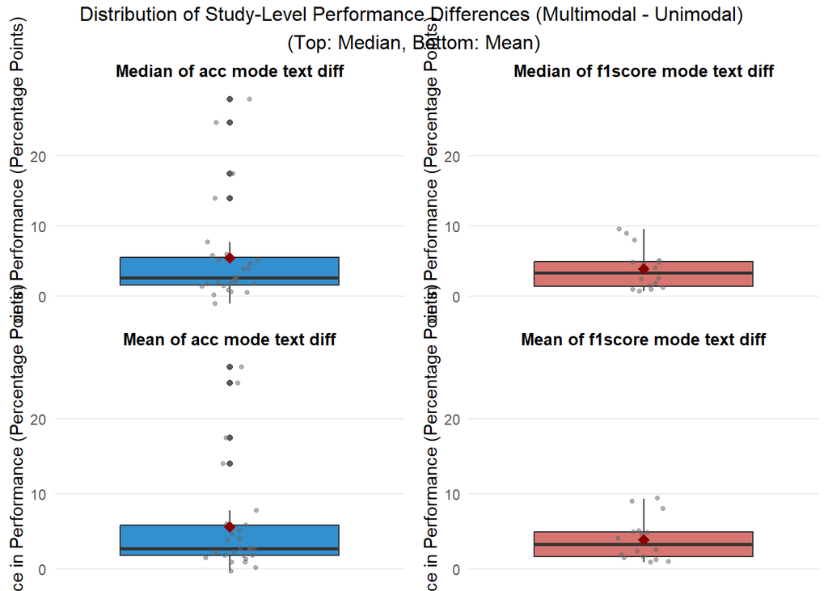

```r
# Calculate y-axis limits for each statistic
median_range <- histogram_data %>%
  filter(statistic == "Median") %>%
  pull(value) %>%
  range(na.rm = TRUE)

mean_range <- histogram_data %>%
  filter(statistic == "Mean") %>%
  pull(value) %>%
  range(na.rm = TRUE)

# Create scaled plots
median_plots_scaled <- lapply(metrics_list, function(metric) {
  create_summary_boxplot_scaled(histogram_data, metric, "Median", median_range, global_palette)
})

mean_plots_scaled <- lapply(metrics_list, function(metric) {
  create_summary_boxplot_scaled(histogram_data, metric, "Mean", mean_range, global_palette)
})

# Arrange scaled version
grid.arrange(grobs = c(median_plots_scaled, mean_plots_scaled),
             ncol = 2, nrow = 2,
             top = "Distribution of Study-Level Performance Differences (Multimodal − Unimodal) \n(Top: Median, Bottom: Mean)")
```

Visualization to article

```r
clean_data <- preprocess_for_plotting(histogram_data)

table(clean_data$Metric)
```

```
##
## Accuracy F1 Score
##       54       32
```

```r
table(histogram_data$Metric)
```

```
##
##     acc_mode_text_diff f1score_mode_text_diff
##                     54                     32
```

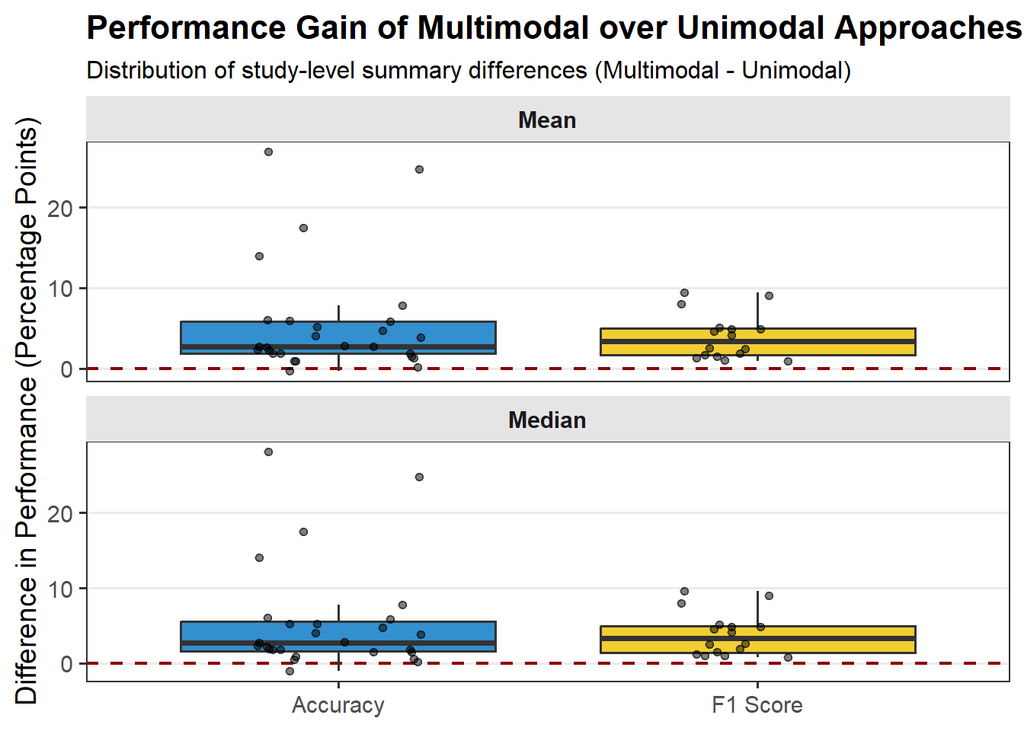

```r
metric_names <- c("Accuracy", "F1 Score")
palette_colors <- pal_jco("default")(length(metric_names))
my_palette <- setNames(palette_colors, metric_names)

final_faceted_plot <- create_faceted_plot(clean_data, palette = my_palette, title = "Performance Gain of Multimodal over Unimodal Approaches", subtitle = "Distribution of study-level summary differences (Multimodal − Unimodal)")

final_faceted_plot
```

```r
ggplot2::ggsave("fig-mm-difference.pdf", final_faceted_plot, width = 7.42, height = 8.46, units="in")
```

#### 4.3.1.2 Performs the Shapiro-Wilk test of normality of difference metrics’ values

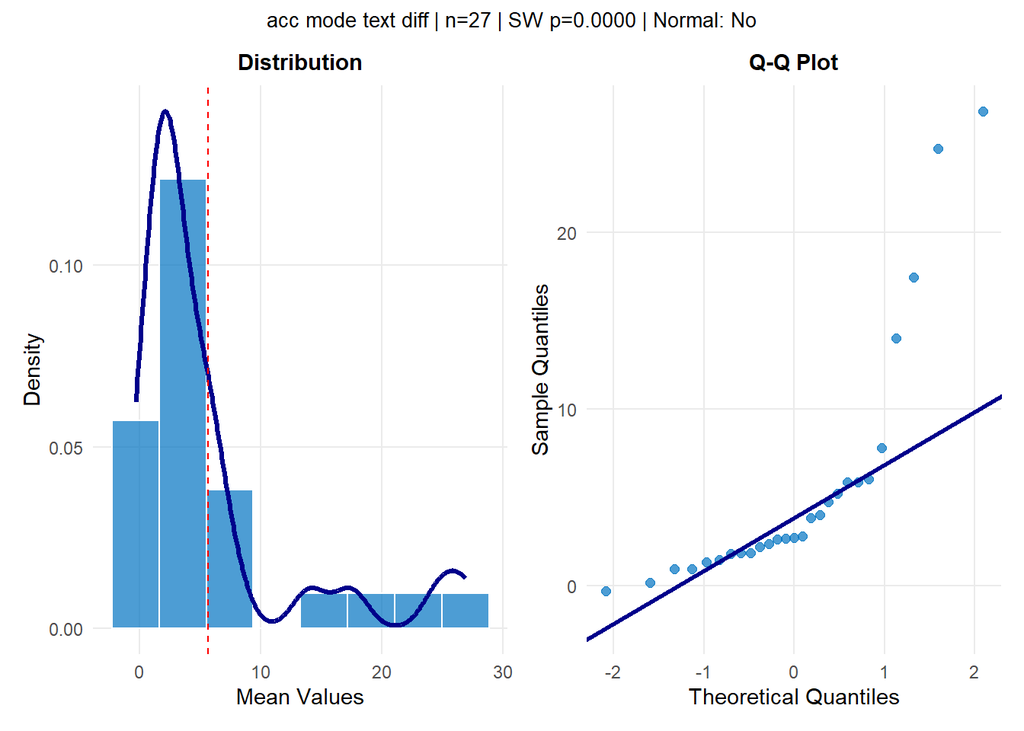

```r
global_palette <- stats::setNames(
  grDevices::colorRampPalette(ggsci::pal_jco("default")(2))(2),
  unique(histogram_data$Metric)
)

create_normality_plots(histogram_data, 'acc_mode_text_diff', global_palette)
```

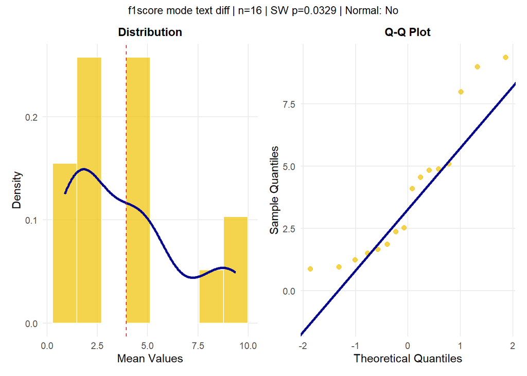

```r
global_palette <- stats::setNames(
  grDevices::colorRampPalette(ggsci::pal_jco("default")(2))(2),
  unique(histogram_data$Metric)
)

create_normality_plots(histogram_data, 'f1score_mode_text_diff', global_palette)
```

Global statistics mean of means and median of medians.

```r
# Create summary statistics grouped by Metric and statistic
histogram_summary <- histogram_data %>%
  group_by(.data[['Metric']], .data[['statistic']]) %>%
  summarise(
    summary_stats_grouped(value),
    .groups = "drop"
  )

knitr::kable(histogram_summary,
             caption = "Summary Statistics of Mean and Median Differences Values by Metric.",
             digits = 3) %>%
  kableExtra::kable_styling(bootstrap_options = c("striped", "hover")) %>%
  kableExtra::collapse_rows(columns = 1, valign = "top")
```

Table 4.23: Table 4.24: Summary Statistics of Mean and Median Differences Values by Metric.

| Metric | statistic | Count | Min | Q1 | Median | Mean | Q3 | Max | SD |
| --- | --- | --- | --- | --- | --- | --- | --- | --- | --- |
| acc_mode_text_diff | Mean | 27 | -0.333 | 1.810 | 2.700 | 5.617 | 5.862 | 26.874 | 7.029 |
|  | Median | 27 | -1.000 | 1.650 | 2.700 | 5.505 | 5.525 | 28.090 | 7.255 |
| f1score_mode_text_diff | Mean | 16 | 0.882 | 1.628 | 3.315 | 3.933 | 4.950 | 9.375 | 2.832 |
|  | Median | 16 | 0.750 | 1.444 | 3.350 | 3.909 | 4.912 | 9.550 | 2.891 |

Prepare table to article

```r
clean_data <- preprocess_for_plotting(histogram_data)

summary_table_data <- clean_data %>%
  group_by(Metric, statistic) %>%
  summarise(
    N = n(),
    Min = min(Difference, na.rm = TRUE),
    Q1 = quantile(Difference, 0.25, na.rm = TRUE),
    Median = median(Difference, na.rm = TRUE),
    Mean = mean(Difference, na.rm = TRUE),
    Q3 = quantile(Difference, 0.75, na.rm = TRUE),
    Max = max(Difference, na.rm = TRUE),
    SD = sd(Difference, na.rm = TRUE),
    .groups = "drop" # Ungroup after summarising
  ) %>%
  # Arrange for better readability
  arrange(Metric, statistic)
```

```r
knitr::kable(summary_table_data,
             caption = "Descriptive Statistics for Study-Level Performance Differences.",
             digits = 3) %>%
  kableExtra::kable_styling(bootstrap_options = c("striped", "hover")) %>%
  kableExtra::collapse_rows(columns = 1, valign = "top")
```

Table 4.25: Table 4.26: Descriptive Statistics for Study-Level Performance Differences.

| Metric | statistic | N | Min | Q1 | Median | Mean | Q3 | Max | SD |
| --- | --- | --- | --- | --- | --- | --- | --- | --- | --- |
| Accuracy | Mean | 27 | -0.333 | 1.810 | 2.700 | 5.617 | 5.862 | 26.874 | 7.029 |
|  | Median | 27 | -1.000 | 1.650 | 2.700 | 5.505 | 5.525 | 28.090 | 7.255 |
| F1 Score | Mean | 16 | 0.882 | 1.628 | 3.315 | 3.933 | 4.950 | 9.375 | 2.832 |
|  | Median | 16 | 0.750 | 1.444 | 3.350 | 3.909 | 4.912 | 9.550 | 2.891 |

```r
latex_table_code <- summary_table_data %>%
  # Use kable() with formatting for LaTeX
  kable(
    format = "latex",
    booktabs = TRUE, # Creates professional horizontal lines (\toprule, \midrule, etc.)
    digits = 2,      # Round all numbers to 2 decimal places
    caption = "Descriptive Statistics for Study-Level Performance Differences.",
    label = "tab:summary_stats", # For referencing in text with \ref{tab:summary_stats}
    col.names = c("Metric", "Stat.", "N", "Min", "Q1", "Median", "Mean", "Q3", "Max", "SD")
  ) %>%
  # Use kable_styling for a better look
  kable_styling(latex_options = c("striped", "scale_down")) %>%
  # Group rows by Metric for excellent readability
  group_rows(index = table(summary_table_data$Metric))

# Print the code to the console
print(latex_table_code)
```

```
## \begin{table}
## \centering
## \caption{(\#tab:tab:summary_stats)Descriptive Statistics for Study-Level Performance Differences.}
## \centering
## \resizebox{\ifdim\width>\linewidth\linewidth\else\width\fi}{!}{
## \begin{tabular}[t]{llrrrrrrrr}
## \toprule
## Metric & Stat. & N & Min & Q1 & Median & Mean & Q3 & Max & SD\\
## \midrule
## \addlinespace[0.3em]
## \multicolumn{10}{l}{\textbf{Accuracy}}\\
## \hspace{1em}\cellcolor{gray!10}{Accuracy} & \cellcolor{gray!10}{Mean} & \cellcolor{gray!10}{27} & \cellcolor{gray!10}{-0.33} & \cellcolor{gray!10}{1.81} & \cellcolor{gray!10}{2.70} & \cellcolor{gray!10}{5.62} & \cellcolor{gray!10}{5.86} & \cellcolor{gray!10}{26.87} & \cellcolor{gray!10}{7.03}\\
## \hspace{1em}Accuracy & Median & 27 & -1.00 & 1.65 & 2.70 & 5.51 & 5.52 & 28.09 & 7.26\\
## \addlinespace[0.3em]
## \multicolumn{10}{l}{\textbf{F1 Score}}\\
## \hspace{1em}\cellcolor{gray!10}{F1 Score} & \cellcolor{gray!10}{Mean} & \cellcolor{gray!10}{16} & \cellcolor{gray!10}{0.88} & \cellcolor{gray!10}{1.63} & \cellcolor{gray!10}{3.31} & \cellcolor{gray!10}{3.93} & \cellcolor{gray!10}{4.95} & \cellcolor{gray!10}{9.38} & \cellcolor{gray!10}{2.83}\\
## \hspace{1em}F1 Score & Median & 16 & 0.75 & 1.44 & 3.35 & 3.91 & 4.91 & 9.55 & 2.89\\
## \bottomrule
## \end{tabular}}
## \end{table}
```

Our choice of statistical tests was guided as before for multiview approaches analysis.

### 4.3.2 Inferential Testing Across Studies: Statistical tests of the difference in the distributions of metrics values

#### 4.3.2.1 Permutation test

```r
# Define metrics from histogram_data
metrics <- unique(histogram_data$Metric)

# Run the permutation test for each metric
all_perm_stats <- t(sapply(metrics, get_permutation_stats, data = histogram_data))

# Convert to a data frame for nice formatting
results_perm <- data.frame(
  metric = metrics,
  all_perm_stats,
  significant = ifelse(!is.na(all_perm_stats[, "p_value"]) & all_perm_stats[, "p_value"] < 0.05, "Yes", "No"),
  stars = ifelse(
    is.na(all_perm_stats[, "p_value"]), "NA",
    ifelse(all_perm_stats[, "p_value"] < 0.001, "***",
    ifelse(all_perm_stats[, "p_value"] < 0.01, "**",
    ifelse(all_perm_stats[, "p_value"] < 0.05, "*", "ns")))
  ),
  effect = ifelse(
    is.na(all_perm_stats[, "cohens_d"]), "NA",
    # Interpretation for Cohen's d
    # Note: we use abs() for magnitude regardless of direction
    ifelse(abs(all_perm_stats[, "cohens_d"]) < 0.2, "Negligible",
    ifelse(abs(all_perm_stats[, "cohens_d"]) < 0.5, "Small",
    ifelse(abs(all_perm_stats[, "cohens_d"]) < 0.8, "Medium", "Large")))
  )
)

rownames(results_perm) <- NULL
```

```r
knitr::kable(results_perm,
             caption = "Permutation test - Testing if mean differences differ from zero.",
             col.names = c("Metric", "Observed Mean", "p-value", "Cohen's d", "n", "Significant (p<0.05)", " ", "Effect Size"),
             digits = 3) %>%
  kableExtra::kable_styling(bootstrap_options = "striped", full_width = FALSE)
```

Table 4.27: Table 4.28: Permutation test - Testing if mean differences differ from zero.

| Metric | Observed Mean | p-value | Cohen’s d | n | Significant (p<0.05) |  | Effect Size |
| --- | --- | --- | --- | --- | --- | --- | --- |
| acc_mode_text_diff | 5.617 | 0 | 0.799 | 27 | Yes | *** | Medium |
| f1score_mode_text_diff | 3.933 | 0 | 1.389 | 16 | Yes | *** | Large |

To test for a significant difference, a one-sample permutation test (9,999 permutations) was conducted on the paired performance differences. The results demonstrate a clear and consistently positive effect of multimodality on the mean performance. For **Accuracy**, the multimodal approach yielded a mean improvement of **5.62 percentage points** (N=27, p < .001), a robust effect size (Cohen’s d = 0.80). A similarly significant enhancement was observed for the **F1-score**, which increased by an average of **3.93 points** (N=16, p < .001) with a large corresponding effect size (Cohen’s d = 1.39).

In summary, these findings provide strong statistical evidence that augmenting text-based models with additional modalities is a highly effective strategy for significantly enhancing classification performance.

#### 4.3.2.2 Wilcoxon signed-rank test and effect size r (rank-biserial correlation)

```r
metrics <- unique(histogram_data$Metric)

# Get all test results using the function
all_stats_corrected <- t(sapply(metrics, get_wilcox_stats_corrected, data = histogram_data))

# Convert to data frame and add interpretations
results_corrected <- data.frame(
  metric = metrics,
  all_stats_corrected,
  significant = ifelse(!is.na(all_stats_corrected[, "p"]) & all_stats_corrected[, "p"] < 0.05, "Yes", "No"),
  stars = ifelse(is.na(all_stats_corrected[, "p"]), "NA",
                 ifelse(all_stats_corrected[, "p"] < 0.001, "***",
                 ifelse(all_stats_corrected[, "p"] < 0.01, "**",
                 ifelse(all_stats_corrected[, "p"] < 0.05, "*", "ns")))),
  effect = ifelse(is.na(all_stats_corrected[, "r"]), "NA",
                  ifelse(abs(all_stats_corrected[, "r"]) < 0.1, "Negligible",
                  ifelse(abs(all_stats_corrected[, "r"]) < 0.3, "Small",
                  ifelse(abs(all_stats_corrected[, "r"]) < 0.5, "Medium", "Large"))))
)


rownames(results_corrected) <- NULL
```

```r
# Create formatted table
knitr::kable(results_corrected,
             caption = "Wilcoxon signed-rank test - Testing if mean differences differ from zero",
             digits = 4) %>%
  kableExtra::kable_styling()
```

Table 4.29: Table 4.30: Wilcoxon signed-rank test - Testing if mean differences differ from zero

| metric | V | p | r | n | CI | CI_Lower | CI_Upper | Mean_Difference | Median_Difference | significant | stars | effect |
| --- | --- | --- | --- | --- | --- | --- | --- | --- | --- | --- | --- | --- |
| acc_mode_text_diff | 376 | 0 | 0.9894 | 27 | 0.95 | 0.9751 | 0.9955 | 5.6167 | 2.700 | Yes | *** | Large |
| f1score_mode_text_diff | 136 | 0 | 1.0000 | 16 | 0.95 | 1.0000 | 1.0000 | 3.9334 | 3.315 | Yes | *** | Large |

To assess the robustness of these findings to potential outliers, we conducted a non-parametric Wilcoxon signed-rank test. This test strongly corroborates our initial findings by confirming a highly significant positive shift in the median performance difference for both **Accuracy** (V = 376, p < .001) and **F1-score** (V = 136, p < .001). This indicates the advantage of multimodality is a consistent positive shift in typical performance, not merely an artifact of the mean being skewed by extreme values. While the associated rank-biserial correlation effect size (r) was large for both, the significant p-values provide the most reliable evidence of a genuine effect.

#### 4.3.2.3 Calculate Cliff’s Delta

Cliff’s Delta (d) is an effect size of dominance. It answers the question:

- If I pick a random value from group A and a random value from group B, what is the probability that the value from A is larger, minus the probability that the value from B is larger? (It ranges from -1 to 1.)

```r
# Define the metrics
metrics <- c("acc", "f1score")
# Initialize data frame to store results
cliff_summary <- data.frame(
  Metric = character(),
  Delta = numeric(),
  CI_Lower = numeric(),
  CI_Upper = numeric(),
  Magnitude = character(),
  N = integer(),
  Mean_Single = numeric(),
  Mean_Combo = numeric(),
  stringsAsFactors = FALSE
)

# Calculate Cliff's Delta for each metric
for (metric in metrics) {
  # Prepare data for this metric
  cliff_data <- prepare_cliff_data(metric, data_clean, aggregation_method = "mean", single_col = ".mode.text", combo_col = ".mode.text.image")

  # Skip if no valid data
  if (is.null(cliff_data) || nrow(cliff_data) < 3) {
    next
  }

  # Calculate Cliff's Delta (combinations vs single)
  result <- cliff.delta(cliff_data$combo_view, cliff_data$single_view, paired = TRUE)

  # Add to summary data frame
  cliff_summary <- rbind(
    cliff_summary,
    data.frame(
      Metric = metric,
      Delta = result$estimate,
      CI_Lower = result$conf.int[1],
      CI_Upper = result$conf.int[2],
      Magnitude = result$magnitude,
      N = nrow(cliff_data),
      Mean_Single = mean(cliff_data$single_view),
      Mean_Combo = mean(cliff_data$combo_view),
      Mean_Difference = mean(cliff_data$combo_view)-mean(cliff_data$single_view),
      stringsAsFactors = FALSE
    )
  )
}

rownames(cliff_summary) <- NULL
```

```r
knitr::kable(cliff_summary,
             caption = "Cliff's Delta - Effect Size for Combinations vs Single View (Levels: negligible < small < medium < large)",
             digits = 4) %>%
  kableExtra::kable_styling()
```

Table 4.31: Table 4.32: Cliff’s Delta - Effect Size for Combinations vs Single View (Levels: negligible < small < medium < large)

| Metric | Delta | CI_Lower | CI_Upper | Magnitude | N | Mean_Single | Mean_Combo | Mean_Difference |
| --- | --- | --- | --- | --- | --- | --- | --- | --- |
| acc | 0.3086 | -0.0107 | 0.5708 | small | 27 | 75.5168 | 81.1335 | 5.6167 |
| f1score | 0.2656 | -0.1517 | 0.6026 | small | 16 | 77.9150 | 81.8485 | 3.9334 |

```r
# Print formatted results
cat("\nCliff's Delta Effect Size Results (Combinations vs Single View):\n")
```

```
##
## Cliff's Delta Effect Size Results (Combinations vs Single View):
```

```r
cat("================================================================\n")
for (i in 1:nrow(cliff_summary)) {
  row <- cliff_summary[i, ]
  cat(
    sprintf(
      "\n%s: δ = %.4f (95%% CI: %.4f to %.4f), %s effect, n = %d\n",
      toupper(row$Metric),
      row$Delta,
      row$CI_Lower,
      row$CI_Upper,
      row$Magnitude,
      row$N
    )
  )
  cat(sprintf("  Mean Single View: %.2f, Mean Combinations: %.2f\n",
              row$Mean_Single, row$Mean_Combo))
}
```

```
##
## ACC: d = 0.3086 (95% CI: -0.0107 to 0.5708), small effect, n = 27
##   Mean Single View: 75.52, Mean Combinations: 81.13
##
## F1SCORE: d = 0.2656 (95% CI: -0.1517 to 0.6026), small effect, n = 16
##   Mean Single View: 77.92, Mean Combinations: 81.85
```

To quantify the effect size from a non-parametric, probabilistic perspective, we calculated Cliff’s Delta. This metric assesses the probability that a randomly chosen multimodal system outperforms a unimodal one. For **Accuracy**, the delta of **0.31** suggests a small-to-medium probabilistic advantage. For **F1-Score**, the delta was **0.27**.

Critically, for both metrics, the 95% confidence intervals were wide and crossed zero (Accuracy CI: [-0.01, 0.57]; F1-Score CI: [-0.15, 0.60]). This finding adds crucial nuance to our analysis. While the permutation and Wilcoxon tests confirm the *average* effect is likely not zero, the Cliff’s Delta CIs reveal substantial **uncertainty about the effect’s magnitude and consistency.** The data are compatible with anything from a negligible effect to a large one, highlighting the variability in outcomes across studies.

### 4.3.3 Discussion

Our preliminary statistical tests paint a nuanced and consistent picture. On one hand, both the permutation and Wilcoxon signed-rank tests provide strong, converging evidence that the central tendency (mean and median) of the performance improvement is significantly greater than zero for both Accuracy and F1-Score. This confirms a genuine positive effect is present.

On the other hand, the Cliff’s Delta analysis reveals that despite the positive average effect, there is considerable uncertainty and variability in the magnitude of this effect. The wide confidence intervals, which include zero, indicate that while the multimodal approach is beneficial on average, we cannot be highly confident in the consistency or size of this advantage from one context to another.

Together, these findings motivate the need for a formal meta-analysis. We have established an average positive effect, but to properly quantify the magnitude of this effect and, most importantly, to investigate the sources of the high variability between studies, a more sophisticated modeling approach is required.

## 4.4 Meta-analysisi: A deeper insight analysis

Our meta-analyses are based on a relatively small number of studies for each outcome metric (k ranges from 16 to 27). In such cases, standard meta-analytic methods can underestimate the between-study variance and produce overly narrow confidence intervals, potentially leading to an increased risk of Type I errors. To address this, we employ Robust Variance Estimation (RVE), as implemented in the R package clubSandwich. The RVE method provides more conservative and reliable confidence intervals and p-values, making our findings more trustworthy and defensible given the size of our sample.

Our primary analytical model is a weighted random-effects model using Robust Variance Estimation. This model is our most defensible estimate, as it weights studies by their precision (inverse variance) while applying the necessary small-sample corrections. To assess the robustness of our findings, we also present results from an unweighted RVE model, which treats each study equally, regardless of its precision. Finally, for transparency and to illustrate the impact of the RVE correction, we also report the results from a standard random-effects model without the robust estimation. This report will apply this analytical strategy to two key performance metrics: Accuracy and F1-Score.

Several key decisions and assumptions underpin our statistical models:

- Effect Size Metric: As all primary outcome metrics (Accuracy, F1-Score) are reported on a common percentage scale (0-100), we selected the Raw Mean Difference (RMD) as our effect size for its direct interpretability. The effect size for each study i was calculated as yi = Mean_multimodal - Mean_unimodal.
- Imputation of Missing Standard Deviations: A subset of studies reported performance as a single point estimate without a measure of variance (i.e., standard deviation). For these studies, we imputed the standard deviation using the pooled average SD calculated from studies that did provide this information, a common practice in meta-analysis to enable their inclusion in a weighted model.
- Study-Level Variance Calculation: The variance of the mean difference for each study was calculated under the assumption of independent groups. We acknowledge this is a simplification, as the unimodal and multimodal results from a single paper are inherently paired and thus correlated. However, as the within-study correlation (ri) is almost never reported, this assumption is a practical necessity. It is a limitation of this report, and by ignoring a likely positive correlation, our calculation may overestimate the true study-level sampling variance.

```r
metrics_to_analyze <- list(
  list(comb = "acc.mode.text.image", single = "acc.mode.text", name = "Accuracy"),
  list(comb = "f1score.mode.text.image", single = "f1score.mode.text", name = "F1-Score")
)

all_results <- list()

for (metric in metrics_to_analyze) {
  all_results[[metric$name]] <- perform_meta_analysis(
    raw_data_frame = data_filled,
    col_comb = metric$comb,
    col_single = metric$single,
    metric_name = metric$name
  )
}
```

### 4.4.1 Publication bias analysis

```r
metric_names <- names(all_results) # e.g., "Accuracy", "F1-Score", "Precision", "Recall"
print(metric_names)
```

```
## [1] "Accuracy" "F1-Score"
```

```r
name <- "Accuracy"
check_publication_bias(all_results[[name]], name, "mm")
```

```
##
## ==============================================
## PUBLICATION BIAS ANALYSIS: Accuracy (k=27)
## ==============================================
```

```
## [File saved]: Funnel plot saved to fig-mm-funnel-accuracy.pdf
```

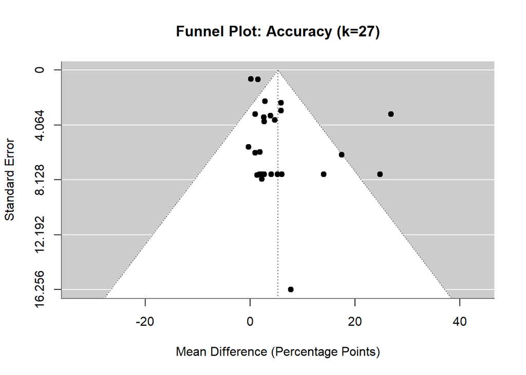

```
##
## Egger's Regression Test Results:
##
## Regression Test for Funnel Plot Asymmetry
##
## Model:     mixed-effects meta-regression model
## Predictor: standard error
##
## Test for Funnel Plot Asymmetry: z = 0.6683, p = 0.5039
## Limit Estimate (as sei -> 0):   b = 3.6298 (CI: -1.9933, 9.2529)
##
## --> Result: No significant asymmetry detected (p >= 0.05).
```

```r
name <- "F1-Score"
check_publication_bias(all_results[[name]], name, "mm")
```

```
##
## ==============================================
## PUBLICATION BIAS ANALYSIS: F1-Score (k=16)
## ==============================================
```

```
## [File saved]: Funnel plot saved to fig-mm-funnel-f1-score.pdf
```

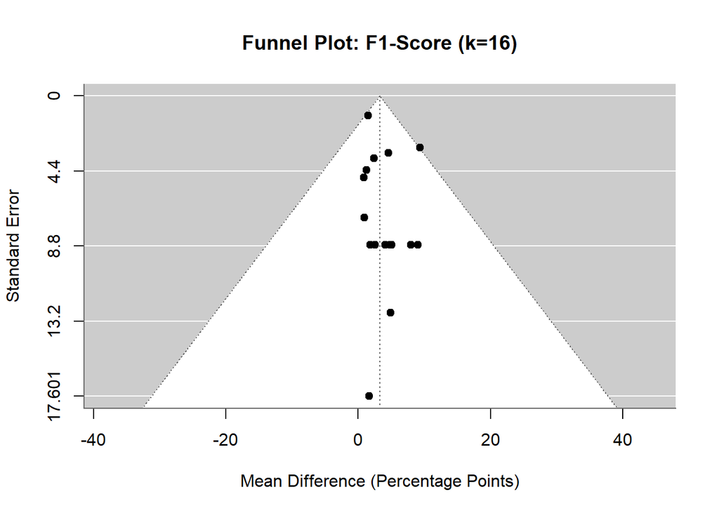

```
##
## Egger's Regression Test Results:
##
## Regression Test for Funnel Plot Asymmetry
##
## Model:     mixed-effects meta-regression model
## Predictor: standard error
##
## Test for Funnel Plot Asymmetry: z = 0.6404, p = 0.5219
## Limit Estimate (as sei -> 0):   b = 2.3056 (CI: -1.2754, 5.8865)
##
## --> Result: No significant asymmetry detected (p >= 0.05).
```

### 4.4.2 Standard (Inverse-Variance Weighted) Random-Effects Model (Gold Standard)

This model answers the question:

- What is the average effect if we give more weight to studies that provide more precise estimates (i.e., larger n, smaller sd)? This is the standard approach. To do this, we need to handle the studies with n=1. The best practice is data imputation: we will “fill in” a reasonable estimate for the missing standard deviations.

#### 4.4.2.1 Weighted Random-Effects Model: Accuracy

```r
print("--- Weighted Model (All studies equal): Accuracy ---")
```

```
## [1] "--- Weighted Model (All studies equal): Accuracy ---"
```

```r
summary(all_results$Accuracy$weighted_rve)
```

```
##
## Random-Effects Model (k = 27; tau^2 estimator: REML)
##
##   logLik  deviance       AIC       BIC      AICc
## -89.3131  178.6263  182.6263  185.1425  183.1480
##
## tau^2 (estimated amount of total heterogeneity): 30.8582 (SE = 14.8094)
## tau (square root of estimated tau^2 value):      5.5550
## I^2 (total heterogeneity / total variability):   82.63%
## H^2 (total variability / sampling variability):  5.76
##
## Test for Heterogeneity:
## Q(df = 26) = 90.7360, p-val < .0001
##
## Number of estimates:   27
## Number of clusters:    27
## Estimates per cluster: 1
##
## Model Results:
##
## estimate      se¹    tval¹     df¹    pval¹   ci.lb¹   ci.ub¹
##   5.2760  1.4652   3.6010   21.62   0.0016   2.2344   8.3177   **
##
## ---
## Signif. codes:  0 '***' 0.001 '**' 0.01 '*' 0.05 '.' 0.1 ' ' 1
##
## 1) results based on cluster-robust inference (var-cov estimator: CR2,
##    approx t-test and confidence interval, df: Satterthwaite approx)
```

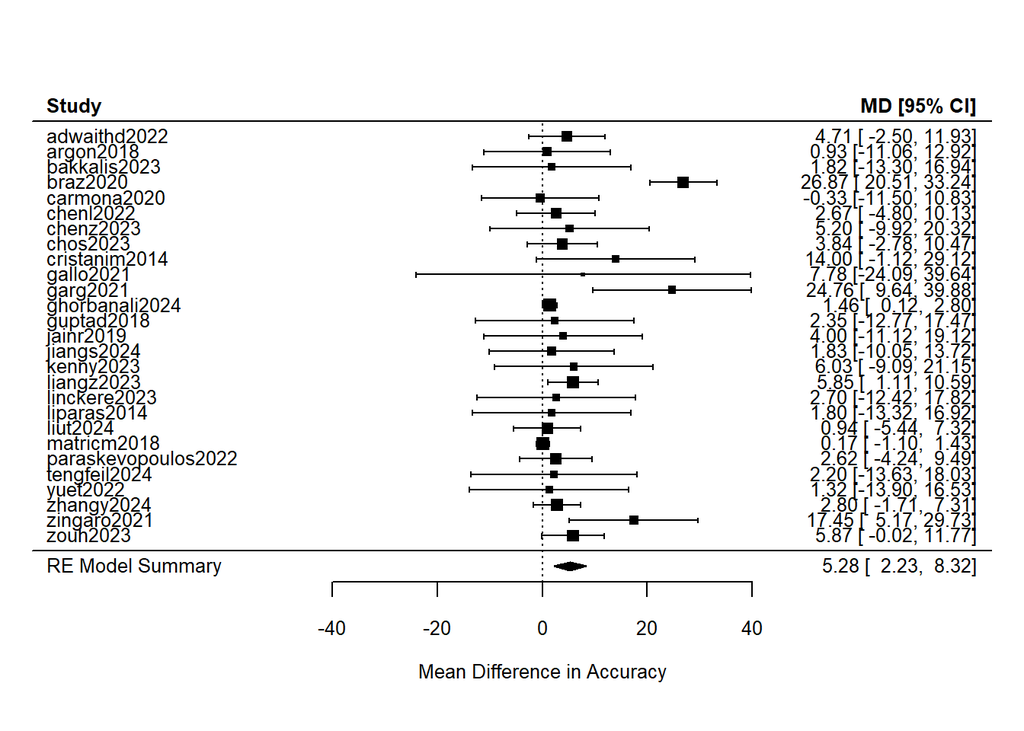

```r
forest(all_results$Accuracy$weighted_rve,
       slab = all_results$Accuracy$effect_sizes$studylab,
       header = "Study",
       xlab = "Mean Difference in Accuracy",
       mlab = "RE Model Summary",
       cex = 0.8)
```

```r
print("--- Weighted Model (All studies equal): Accuracy ---")
```

```
## [1] "--- Weighted Model (All studies equal): Accuracy ---"
```

```r
summary(all_results$Accuracy$weighted)
```

```
##
## Random-Effects Model (k = 27; tau^2 estimator: REML)
##
##   logLik  deviance       AIC       BIC      AICc
## -89.3131  178.6263  182.6263  185.1425  183.1480
##
## tau^2 (estimated amount of total heterogeneity): 30.8582 (SE = 14.8094)
## tau (square root of estimated tau^2 value):      5.5550
## I^2 (total heterogeneity / total variability):   82.63%
## H^2 (total variability / sampling variability):  5.76
##
## Test for Heterogeneity:
## Q(df = 26) = 90.7360, p-val < .0001
##
## Model Results:
##
## estimate      se    zval    pval   ci.lb   ci.ub
##   5.2760  1.4627  3.6069  0.0003  2.4091  8.1429  ***
##
## ---
## Signif. codes:  0 '***' 0.001 '**' 0.01 '*' 0.05 '.' 0.1 ' ' 1
```

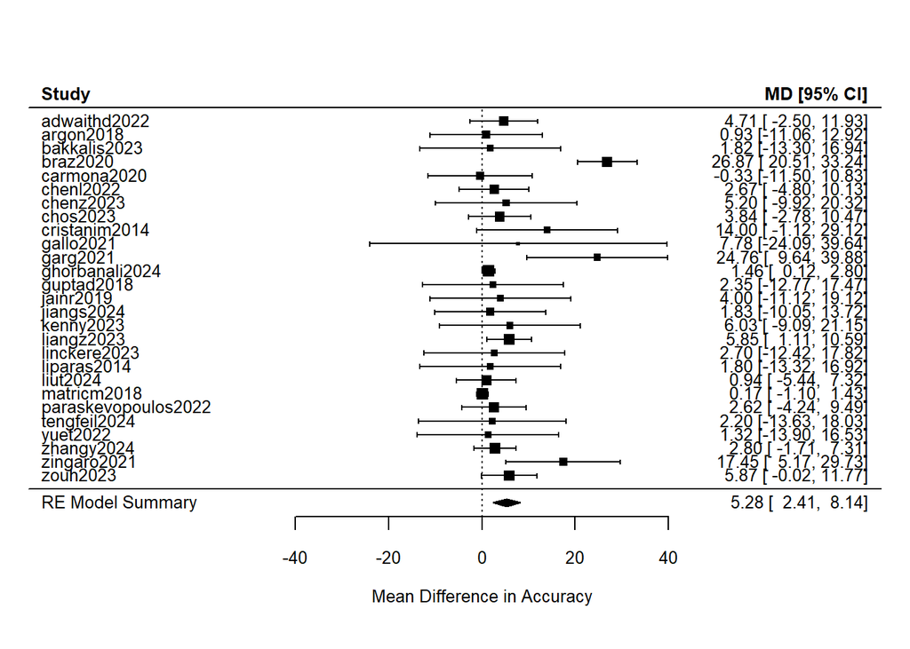

```r
forest(all_results$Accuracy$weighted,
       slab = all_results$Accuracy$effect_sizes$studylab,
       header = "Study",
       xlab = "Mean Difference in Accuracy",
       mlab = "RE Model Summary",
       cex = 0.8)
```

Our primary meta-analysis for the Accuracy metric was performed on 27 studies using a robust random-effects model with inverse-variance weighting. This approach gives more weight to studies providing more precise estimates, while the robust variance estimation corrects for the small number of studies, providing more reliable confidence intervals and p-values.

The analysis revealed a statistically significant overall benefit for multimodal approaches. On average, multimodal models outperformed their strongest unimodal counterparts by an estimated +5.28 percentage points in accuracy (95% CI: [2.23, 8.32], p = 0.0016). The fact that the confidence interval is entirely above zero provides strong evidence that this advantage is not due to chance.

However, this overall effect must be interpreted with caution due to the extremely high heterogeneity observed between studies (I² = 82.63%, Q(26) = 90.7, p < .0001). This indicates that a single summary estimate of +5.28 does not tell the whole story; the true advantage of multimodality is highly variable and likely depends on factors such as the specific task, the modalities being fused, or the dataset used. Therefore, while we can confidently conclude that an advantage exists on average, the primary finding is the variability of this advantage. This high I² value necessitates further investigation through subgroup analysis to explore the sources of this variation.

#### 4.4.2.2 Weighted Random-Effects Model: F1-score

```r
print("--- Weighted Model (All studies equal): F1-score ---")
```

```
## [1] "--- Weighted Model (All studies equal): F1-score ---"
```

```r
summary(all_results$`F1-Score`$weighted_rve)
```

```
##
## Random-Effects Model (k = 16; tau^2 estimator: REML)
##
##   logLik  deviance       AIC       BIC      AICc
## -45.3939   90.7878   94.7878   96.2039   95.7878
##
## tau^2 (estimated amount of total heterogeneity): 2.2883 (SE = 6.0437)
## tau (square root of estimated tau^2 value):      1.5127
## I^2 (total heterogeneity / total variability):   10.45%
## H^2 (total variability / sampling variability):  1.12
##
## Test for Heterogeneity:
## Q(df = 15) = 7.6409, p-val = 0.9374
##
## Number of estimates:   16
## Number of clusters:    16
## Estimates per cluster: 1
##
## Model Results:
##
## estimate      se¹    tval¹    df¹    pval¹    ci.lb¹   ci.ub¹
##   3.2869  1.2368   2.6575   4.41   0.0511   -0.0237   6.5976   .
##
## ---
## Signif. codes:  0 '***' 0.001 '**' 0.01 '*' 0.05 '.' 0.1 ' ' 1
##
## 1) results based on cluster-robust inference (var-cov estimator: CR2,
##    approx t-test and confidence interval, df: Satterthwaite approx)
```

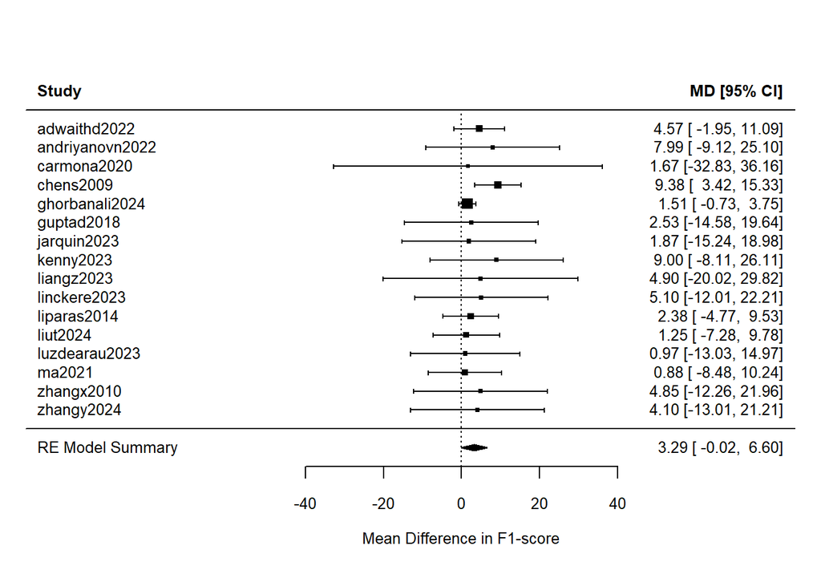

```r
forest(all_results$`F1-Score`$weighted_rve,
       slab = all_results$`F1-Score`$effect_sizes$studylab,
       header = "Study",
       xlab = "Mean Difference in F1-score",
       mlab = "RE Model Summary",
       cex = 0.8)
```

```r
print("--- Weighted Model (All studies equal): F1-score ---")
```

```
## [1] "--- Weighted Model (All studies equal): F1-score ---"
```

```r
summary(all_results$`F1-Score`$weighted)
```

```
##
## Random-Effects Model (k = 16; tau^2 estimator: REML)
##
##   logLik  deviance       AIC       BIC      AICc
## -45.3939   90.7878   94.7878   96.2039   95.7878
##
## tau^2 (estimated amount of total heterogeneity): 2.2883 (SE = 6.0437)
## tau (square root of estimated tau^2 value):      1.5127
## I^2 (total heterogeneity / total variability):   10.45%
## H^2 (total variability / sampling variability):  1.12
##
## Test for Heterogeneity:
## Q(df = 15) = 7.6409, p-val = 0.9374
##
## Model Results:
##
## estimate      se    zval    pval   ci.lb   ci.ub
##   3.2869  1.1885  2.7655  0.0057  0.9574  5.6165  **
##
## ---
## Signif. codes:  0 '***' 0.001 '**' 0.01 '*' 0.05 '.' 0.1 ' ' 1
```

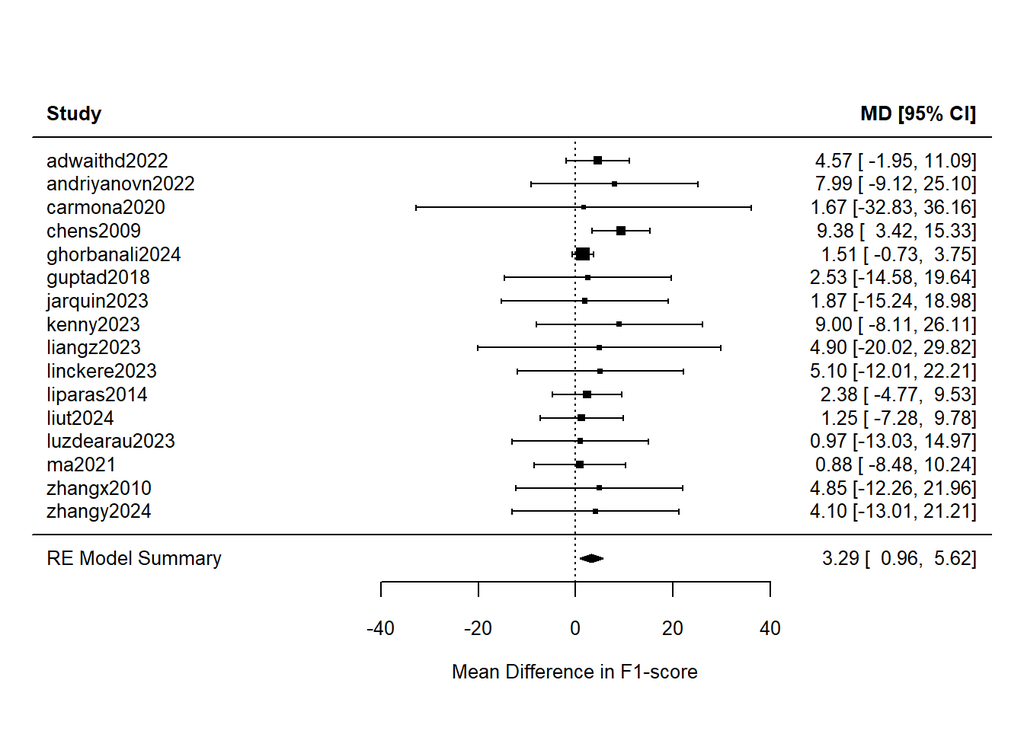

```r
forest(all_results$`F1-Score`$weighted,
       slab = all_results$`F1-Score`$effect_sizes$studylab,
       header = "Study",
       xlab = "Mean Difference in F1-score",
       mlab = "RE Model Summary",
       cex = 0.8)
```

The meta-analysis for F1-Score, performed on 16 studies, yielded notably different results from the Accuracy analysis.

First, we observed a low and statistically non-significant level of heterogeneity (I² = 10.45%, Q(15) = 7.64, p = 0.94). This suggests that the impact of multimodality on F1-Score is far more consistent across different studies, datasets, and tasks than it was for Accuracy.

When synthesizing the results, the choice of statistical model was critical. A standard random-effects model produced a statistically significant result (p = 0.006), suggesting a clear benefit. However, our primary and more appropriate robust random-effects model told a different story.

The robust analysis estimated an average improvement of +3.29 percentage points in F1-Score, but this effect was not statistically significant at the conventional α=0.05 level (95% CI: [-0.02, 6.60], p = 0.051).

Conclusion: Although there is a positive trend suggesting a benefit of around 3 percentage points, the confidence interval narrowly includes zero. Therefore, based on the available evidence, we cannot confidently reject the null hypothesis of no effect. The discrepancy between the standard and robust models highlights the importance of using small-sample corrections; in this case, it prevented a potential Type I error. The finding suggests that while multimodality shows a strong and variable advantage for overall Accuracy, its benefit for the F1-Score—a metric sensitive to class imbalance—is less certain and more modest.

### 4.4.3 Unweighed Random-Effects Model

This model answers the question:

- What is the average effect if we treat every study as equally important, regardless of its size or precision?

#### 4.4.3.1 Unweighed Random-Effects Model: Accuracy

```r
print("--- Unweighted Model (All studies equal): Accuracy ---")
```

```
## [1] "--- Unweighted Model (All studies equal): Accuracy ---"
```

```r
summary(all_results$Accuracy$unweighted_rve)
```

```
##
## Random-Effects Model (k = 27; tau^2 estimator: REML)
##
##   logLik  deviance       AIC       BIC      AICc
## -89.3403  178.6805  182.6805  185.1967  183.2023
##
## tau^2 (estimated amount of total heterogeneity): 30.8582 (SE = 14.8094)
## tau (square root of estimated tau^2 value):      5.5550
## I^2 (total heterogeneity / total variability):   82.63%
## H^2 (total variability / sampling variability):  5.76
##
## Test for Heterogeneity:
## Q(df = 26) = 90.7360, p-val < .0001
##
## Number of estimates:   27
## Number of clusters:    27
## Estimates per cluster: 1
##
## Model Results:
##
## estimate      se¹    tval¹     df¹    pval¹   ci.lb¹   ci.ub¹
##   5.6167  1.3454   4.1747   17.81   0.0006   2.7879   8.4456   ***
##
## ---
## Signif. codes:  0 '***' 0.001 '**' 0.01 '*' 0.05 '.' 0.1 ' ' 1
##
## 1) results based on cluster-robust inference (var-cov estimator: CR2,
##    approx t-test and confidence interval, df: Satterthwaite approx)
```

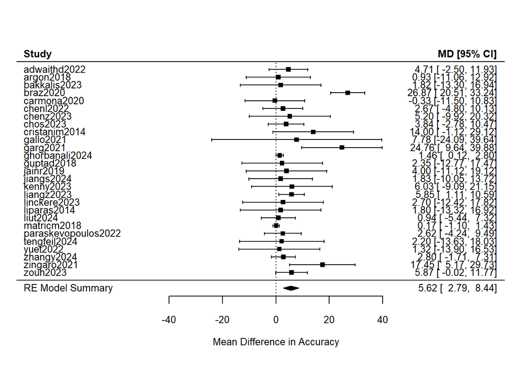

```r
forest(all_results$Accuracy$unweighted_rve,
       slab = all_results$Accuracy$effect_sizes$studylab,
       header = "Study",
       xlab = "Mean Difference in Accuracy",
       mlab = "RE Model Summary",
       cex = 0.8)
```

```r
print("--- Unweighted Model (All studies equal): Accuracy ---")
```

```
## [1] "--- Unweighted Model (All studies equal): Accuracy ---"
```

```r
summary(all_results$Accuracy$unweighted)
```

```
##
## Random-Effects Model (k = 27; tau^2 estimator: REML)
##
##   logLik  deviance       AIC       BIC      AICc
## -89.3403  178.6805  182.6805  185.1967  183.2023
##
## tau^2 (estimated amount of total heterogeneity): 30.8582 (SE = 14.8094)
## tau (square root of estimated tau^2 value):      5.5550
## I^2 (total heterogeneity / total variability):   82.63%
## H^2 (total variability / sampling variability):  5.76
##
## Test for Heterogeneity:
## Q(df = 26) = 90.7360, p-val < .0001
##
## Model Results:
##
## estimate      se    zval    pval   ci.lb   ci.ub
##   5.6167  1.6557  3.3923  0.0007  2.3716  8.8619  ***
##
## ---
## Signif. codes:  0 '***' 0.001 '**' 0.01 '*' 0.05 '.' 0.1 ' ' 1
```

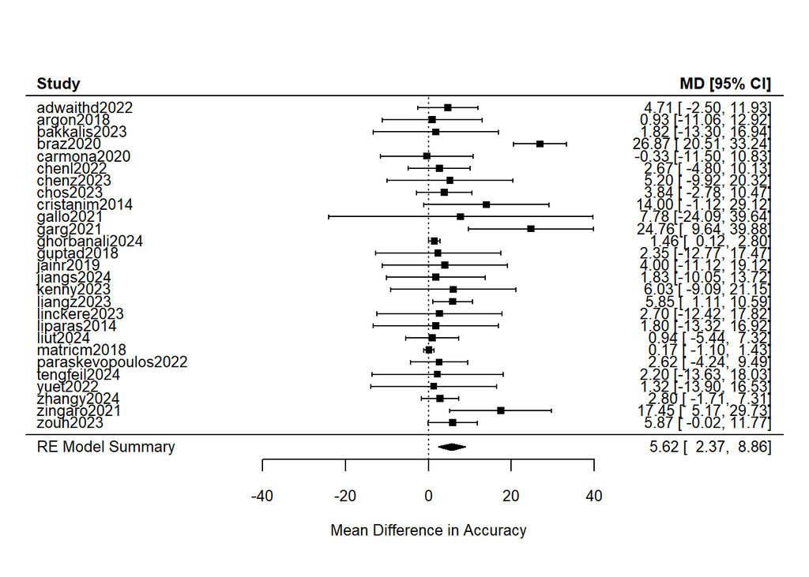

```r
forest(all_results$Accuracy$unweighted,
       slab = all_results$Accuracy$effect_sizes$studylab,
       header = "Study",
       xlab = "Mean Difference in Accuracy",
       mlab = "RE Model Summary",
       cex = 0.8)
```

To test the robustness of our primary finding for the Accuracy metric, we conducted a sensitivity analysis using an unweighed random-effects model. This approach treats each of the 27 studies as equally important, regardless of their individual sample size or precision, providing a check against the possibility that our main result was disproportionately influenced by a few high-precision studies.

The unweighed model corroborates our primary conclusion. The analysis yielded a pooled effect estimate of +5.62 percentage points (95% CI: [2.79, 8.45], p = 0.0006). This result is not only highly statistically significant but also very similar in magnitude to our primary weighted estimate of +5.28.

Conclusion: The consistency of these findings demonstrates that the significant advantage of multimodal approaches for Accuracy is a robust result and not an artifact of the inverse-variance weighting scheme. Whether studies are weighted by their precision or treated as equals, the data converge on the same conclusion: there is a clear and significant performance benefit to using multimodal systems. This strengthens our confidence in the primary analysis.

#### 4.4.3.2 Unweighed Random-Effects Model: F1-score

```r
print("--- Unweighted Model (All studies equal): F1-score ---")
```

```
## [1] "--- Unweighted Model (All studies equal): F1-score ---"
```

```r
summary(all_results$`F1-Score`$unweighted_rve)
```

```
##
## Random-Effects Model (k = 16; tau^2 estimator: REML)
##
##   logLik  deviance       AIC       BIC      AICc
## -45.5418   91.0837   95.0837   96.4998   96.0837
##
## tau^2 (estimated amount of total heterogeneity): 2.2883 (SE = 6.0437)
## tau (square root of estimated tau^2 value):      1.5127
## I^2 (total heterogeneity / total variability):   10.45%
## H^2 (total variability / sampling variability):  1.12
##
## Test for Heterogeneity:
## Q(df = 15) = 7.6409, p-val = 0.9374
##
## Number of estimates:   16
## Number of clusters:    16
## Estimates per cluster: 1
##
## Model Results:
##
## estimate      se¹    tval¹    df¹    pval¹   ci.lb¹   ci.ub¹
##   3.9334  0.6674   5.8937   7.27   0.0005   2.3672   5.4997   ***
##
## ---
## Signif. codes:  0 '***' 0.001 '**' 0.01 '*' 0.05 '.' 0.1 ' ' 1
##
## 1) results based on cluster-robust inference (var-cov estimator: CR2,
##    approx t-test and confidence interval, df: Satterthwaite approx)
```

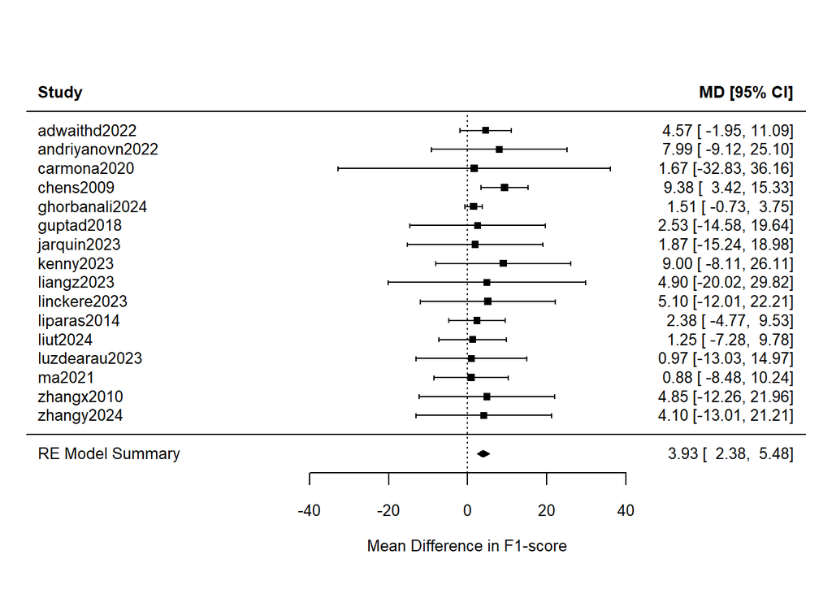

```r
forest(all_results$`F1-Score`$unweighted_rve,
       slab = all_results$`F1-Score`$effect_sizes$studylab,
       header = "Study",
       xlab = "Mean Difference in F1-score",
       mlab = "RE Model Summary",
       cex = 0.8)
```

```r
print("--- Unweighted Model (All studies equal): F1-score ---")
```

```
## [1] "--- Unweighted Model (All studies equal): F1-score ---"
```

```r
summary(all_results$`F1-Score`$unweighted)
```

```
##
## Random-Effects Model (k = 16; tau^2 estimator: REML)
##
##   logLik  deviance       AIC       BIC      AICc
## -45.5418   91.0837   95.0837   96.4998   96.0837
##
## tau^2 (estimated amount of total heterogeneity): 2.2883 (SE = 6.0437)
## tau (square root of estimated tau^2 value):      1.5127
## I^2 (total heterogeneity / total variability):   10.45%
## H^2 (total variability / sampling variability):  1.12
##
## Test for Heterogeneity:
## Q(df = 15) = 7.6409, p-val = 0.9374
##
## Model Results:
##
## estimate      se    zval    pval    ci.lb   ci.ub
##   3.9334  2.1371  1.8406  0.0657  -0.2552  8.1220  .
##
## ---
## Signif. codes:  0 '***' 0.001 '**' 0.01 '*' 0.05 '.' 0.1 ' ' 1
```

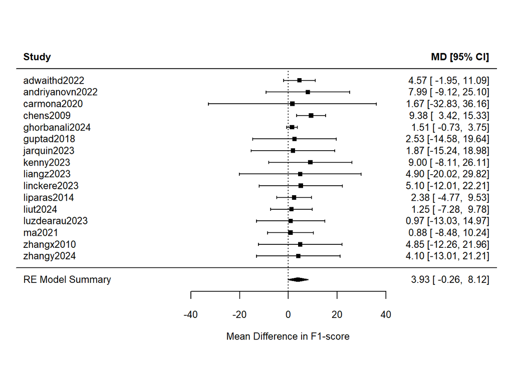

```r
forest(all_results$`F1-Score`$unweighted,
       slab = all_results$`F1-Score`$effect_sizes$studylab,
       header = "Study",
       xlab = "Mean Difference in F1-score",
       mlab = "RE Model Summary",
       cex = 0.8)
```

We next conducted an unweighed sensitivity analysis for the F1-Score to check the robustness of our primary (weighted) finding of a non-significant effect. The results of this analysis were striking and revealed a fundamental instability in the F1-Score data.

In a notable reversal of our primary analysis, the unweighed **robust model showed a highly significant positive effect** of +3.93 percentage points (95% CI: [2.37, 5.50], p = 0.0005). Adding to the complexity, the standard (non-robust) unweighed model applied to the exact same data **did not show a significant effect**, yielding a p-value of 0.0657 (95% CI: [-0.26, 8.12]).

### 4.4.4 Metric values discussion

Below we present table contains all experiment results.

| Metric | Model Type | RVE Correction | Estimate | 95% CI Lower | 95% CI Upper | p-value |
| --- | --- | --- | --- | --- | --- | --- |
| Accuracy | **Weighted** | **Yes** | **5.2760** | **2.2344** | **8.3177** | **0.0016** |
|  | Weighted | No | 5.2760 | 2.4091 | 8.1429 | 0.0003 |
|  | Unweighed | Yes | 5.6167 | 2.7879 | 8.4456 | 0.0006 |
|  | Unweighed | No | 5.6167 | 2.3716 | 8.8619 | 0.0007 |
| F1-score | **Weighted** | **Yes** | **3.2869** | **-0.0237** | **6.5976** | **0.0511** |
|  | Weighted | No | 3.2869 | 0.9574 | 5.6165 | 0.0057 |
|  | Unweighed | Yes | 3.9334 | 2.3672 | 5.4997 | 0.0005 |
|  | Unweighed | No | 3.9334 | -0.2552 | 8.1220 | 0.0657 |

#### 4.4.4.1 Explaining the Divergence Between Accuracy and F1-Score Findings (Weighted Random-Effects Model)

A central finding of our work is the stark contrast between the meta-analytic results for Accuracy (a strong, significant, and highly heterogeneous effect) and F1-Score (a marginal, non-significant, and homogeneous effect). This divergence can be attributed to two fundamental issues revealed by a deeper inspection of the data: differences in the underlying body of evidence and disparities in data quality.

- Data Provenance: The two analyses are not performed on the same set of literature. The Accuracy analysis includes 27 studies, while the F1-Score analysis includes 16, with significant non-overlap between them. They are, in effect, summarizing two different, albeit related, research streams. The literature reporting Accuracy may inherently include more examples of tasks where multimodality provides a profound benefit (e.g., tasks with less class imbalance).
- Data Quality and the Impact of Imputation: The most critical factor is the methodological artifact introduced by the necessary imputation of variance in the F1-Score dataset. Nearly half of the studies (7 of 16) in this analysis were assigned a large, identical variance (vi = 76.2), which had a profound two-fold effect:
  - Artificial Suppression of Heterogeneity: The attribution of large sampling variance to multiple studies led the model to conclude that their effect sizes were consistent with one another, resulting in a low and non-significant heterogeneity estimate (I² = 10.5%). The observed homogeneity is therefore, at least in part, an artifact of data imputation rather than a reflection of true consistency in the field.
  - Distortion of the Pooled Estimate: In an inverse-variance weighted model, these high-variance imputed studies were given minimal weight. Consequently, the final pooled estimate of +3.29 is disproportionately influenced by a small handful of studies that reported very high precision (e.g., ghorbanali2024). This means the F1-Score result is not a robust average across the field but rather reflects the findings of a select few studies.

Conclusion: In summary, the Accuracy result likely reflects a genuine, highly variable performance gain across a broad and diverse set of research contexts. In contrast, the F1-Score result represents a tentative positive trend from a smaller, methodologically compromised dataset. Its marginal, non-significant finding is a product of both a potentially more modest true effect for this metric and statistical artifacts that question the representativeness of the pooled estimate. This highlights a critical challenge for meta-research in machine learning: the conclusions are not only dependent on what is published, but on the quality of the statistical reporting within those publications.

#### 4.4.4.2 F1-Score Findings (Weighted Random-Effects Model) vs Unweighed model results discussion

The meta-analysis for F1-Score produced conflicting results that hinge directly on the choice of statistical model, revealing a fundamental instability in the available evidence. While our primary, “gold standard” weighted analysis suggested a non-significant benefit (+3.29, p = 0.051), a sensitivity analysis using an unweighed “democratic” model showed a notable reversal: a highly significant positive effect of +3.93 percentage points (95% CI: [2.37, 5.50], p = 0.0005).

This reversal demonstrates that the result is highly sensitive to the inverse-variance weighting scheme. The weighted model, compromised by the necessary imputation of large variances for many studies, gave minimal weight to a large portion of the literature. By giving every study an equal vote, the unweighed model revealed that these down-weighted studies tended to report larger effects, pulling the pooled estimate up to a level of clear statistical significance.

This presents a methodological dilemma. We cannot, in good faith, ignore the non-significant result from the standard weighted model. However, the strong positive finding in the unweighed analysis prevents us from definitively concluding there is no effect. This instability, driven by heavy reliance on variance imputation, means the evidence is too methodologically fragile to support a single, confident conclusion.

Therefore, the most responsible interpretation is that while the trend for F1-Score is positive, the true effect cannot be reliably determined without higher-quality statistical reporting in primary studies. This stands in sharp contrast to the robust and consistent findings for the Accuracy metric, where both weighted and unweighed analyses converged on the same significant conclusion.

### 4.4.5 Choosing promising works and discussion

We performed an analysis that identifies the most promising papers and formulates data-driven hypotheses about *why* they performed so well.

#### 4.4.5.1 Strategy: Finding of Promising Papers

The goal is to identify studies that show an unusually large performance gain (a large positive effect size, `yi`) from using a multiview approach. We will use two key criteria:

- **Magnitude of Effect:** Look for the highest `yi` values in both the Accuracy and F1 Score tables.
- **Robustness:** A paper that performs exceptionally well on *both* metrics is a stronger candidate than one that excels at only one.

After identifying the top performers, we will cross-reference them with our taxonomy to uncover patterns in their methods.

#### 4.4.5.2 Analysis and Identification of Promising Papers

Based on the meta-analysis results, three papers stand out as exceptionally promising due to their large and consistent performance gains.

##### 4.4.5.2.1 Promising Paper 1: braz2020

Task: Healthcare (Musculoskeletal Abnormality Detection). This is a high-stakes, specific domain.

Taxonomy Tags: Healthcare, Text + Image, Early Fusion, Domain-specific Dataset.

Data: Accuracy Gain (yi): +26.87 F1-Score Gain (yi): Not Available

Reasoning: Despite lacking F1-Score data, the magnitude of the accuracy improvement is an extreme outlier and cannot be ignored. A gain of nearly 27 percentage points is extraordinary. Understanding this result is critical, even if its robustness is unknown.

Hypothesis for Investigation: The technique in braz2020 might be exceptionally good at solving a specific type of classification problem (e.g., one with a large, easily identifiable negative class, boosting specificity and thus accuracy). Alternatively, the dataset or task may have unique properties that make it especially amenable to their multimodal approach. The investigation should focus on what makes this case so different from the others.

A look at the raw data from one of their experiments reveals the impact:

- image (only): 82.96% acc
- text (synthetic, only): 57.62% acc
- text.image (fused): 84.17% acc

The Multimodal Relationship: Information Condensation In this unique case, the relationship is not natural; it’s engineered. The text modality is not an independent source of information but rather a distilled, semantic summary of the visual modality. Words like “fracture” or “normal wrist” condense the information from thousands of pixels into a handful of high-level concepts.

Challenge: The MURA dataset only has images, not textual reports.

Key Innovation: The authors first trained a caption generator on a different medical dataset (ROCO) to artificially create textual data for the MURA images. They then used a standard DenseNet-169 (image) and BERT (text) model, fusing the features via simple concatenation.

Why It Works: braz2020 is a ground-breaking example of creative data engineering. Its success demonstrates that the benefits of multimodality can be unlocked even when a task is not naturally multimodal, proving that generating a “semantic companion” modality can lead to state-of-the-art results.

Conclusion: The extraordinary performance jump comes from bootstrapping a multimodal solution where one modality was entirely absent. The paper is promising because it demonstrates that even imperfect, artificially generated text can act as a semantic signal to regularize and improve a strong visual classifier. Even though the synthetically generated text is a weak classifier on its own, fusing it with the strong image model provides a consistent and significant performance boost.

##### 4.4.5.2.2 Promising Paper 2: liangz2023

Task: Fake News Detection. This task requires detecting semantic incongruity.

Taxonomy Tags: Fake news detection, Text + Image, Attention Fusion.

This paper is example of a robust positive deviant, showing strong, consistent gains across both metrics.

- Accuracy Effect Size (yi): 5.85
- F1-Score Effect Size (yi): 4.90

Data-Driven Hypothesis: Why is liangz2023 so promising?

Consistent, Reliable Improvement: Unlike the complex interactions in kenny2023, the method in liangz2023 shows a consistently positive and significant gain from adding the image modality across multiple experimental setups. This suggests that their fusion architecture is not a one-off success but is robust and generalizable.

The Multimodal Relationship: Semantic Incongruity Detection In fake news, the text and image are not just complementary; the model must check if they are consistent. Does the image actually depict what the text claims? Is there a subtle mismatch? This is a sophisticated reasoning task.

Key Innovation: This work uses a much more sophisticated architecture. It doesn’t just concatenate unimodal features.

It explicitly uses: A pre-trained Vision-Language model (BLIP) to get a native multimodal representation. A cross-modal attention module to intelligently fuse the features from text (XLNet), image (VGG-19), and the vision-language model (BLIP).

Why It Works: This is precisely what Attention Fusion is designed for. A simple concatenation (braz2020) might not be enough. The cross-modal attention mechanism allows the model to learn which parts of the image are most relevant to which words in the text, and vice-versa. It excels at identifying the subtle (or overt) clashes that are hallmarks of misinformation. The paper’s success is tied to using the right tool (Attention) for a complex reasoning job.

Conclusion: The strength of liangz2023 is not in a single massive gain but in its consistent, robust improvement powered by a state-of-the-art fusion mechanism (attention) designed for complex reasoning.

##### 4.4.5.2.3 Promising Paper 1: kenny2023

Task: Emotion Recognition

Taxonomy Tags: Emotion recognition, Text + Image + Audio, Early Fusion, Domain-specific Dataset (IEMOCAP).

This paper stands out as a strong candidate because it appears high on both the Accuracy and F1-Score lists, demonstrating the robustness.

- Accuracy Effect Size (yi): 6.03
- F1-Score Effect Size (yi): 9.00

Data-Driven Hypothesis: Why is kenny2023 so promising?

Exceptionally Strong Non-Text Modalities: The most striking feature is the incredible performance of the unimodal image (98.4 acc) and audio (98.21 acc) classifiers. They outperform the text modality by a large margin. This is unusual, as text is often the most information-rich modality. This paper tackles a problem where visual and auditory cues are powerful enough to rival or exceed textual information.

Synergy in F1-Score, Not Necessarily Accuracy: While the text.image fusion (93.89 acc) improves upon text-only, it’s actually worse than image-only. However, for the F1-Score, the text.image fusion (76.5) provides a massive +9 point gain over text-only (67.5) and an even larger gain over image-only (57.75).

The Multimodal Relationship: Synergistic Expression In emotion recognition, the tone of voice (audio), facial expression (image/video), and spoken words (text) are all direct, simultaneous signals of the same underlying latent state: the person’s emotion. They are complementary and mutually reinforcing. For example, sarcastic text with a happy tone of voice means something different than sincere text with a happy tone.

Insight: The “Complementary Modalities” Pattern This paper’s success is the textbook example of why multimodality works. It tackles Emotion Recognition, a task where the information is naturally spread across different channels.

- The text provides the semantic content (“what” is being said).
- The image (facial features) provides the visual expression.
- The audio provides the prosody, tone, and intonation (the “how” it is being said).

For a task like emotion, any single modality is insufficient. A sarcastic “That’s great” has positive text but negative audio tone. A pained smile has positive visual cues but negative underlying emotion. kenny2023’s high performance comes from fusing these highly complementary, non-redundant sources of information. The large F1-score gain (+9.00) is a direct result of the audio and visual cues resolving ambiguities that text-only models cannot.

Why It Works: Fusing these highly correlated signals provides a much more complete and robust picture than any single modality alone. The paper succeeded because the fusion captures this synergy, leading to a huge F1-score gain, which balances precision and recall effectively.

#### 4.4.5.3 Hypothesis

Here we define three data-driven hypotheses for multimodal approaches:

**Hypothesis 1: The Semantic Relationship Between Modalities Dictates the Optimal Fusion Strategy.**

- We see two distinct, successful patterns. In kenny2023’s Emotion Recognition task, the modalities (voice, face, text) are synergistic expressions of the same latent state (emotion). Fusing them provides complementary information and yields a massive F1-score gain (+9.00 yi). In contrast, liangz2023’s Fake News Detection task requires checking for semantic incongruity between text and image. This complex reasoning demanded a sophisticated Attention Fusion mechanism. The choice of fusion architecture was dictated not by a general rule, but by the intrinsic relationship between the data sources for that specific task.

**Hypothesis 2: Modal-Level Augmentation is an Efficient Strategy for Unlocking Incremental Gains.**

- The braz2020 paper is the key example. While we point out that the absolute gain over the image-only model is a modest ~1-2 percentage points, the significance of this finding lies not in its magnitude, but in its methodology and efficiency. It Unlocks Performance Where Unimodal Models Plateau: In a competitive domain like medical imaging, a consistent 1-2% gain is highly valuable. braz2020 achieved this not by creating a more complex and expensive vision model, but by adding a cheap, synthetic “semantic hint” via generated text.
- It Represents a New Avenue for Improvement: This strategy suggests that when optimizing a single modality yields diminishing returns, the most efficient path to further improvement may be to augment the data space itself by engineering a companion modality. This is likely more cost-effective than building a new, larger unimodal architecture from scratch for the same incremental gain.

**Hypothesis 3: State-of-the-Art Performance is Driven by the Fusion of Powerful, Pre-trained Unimodal Backbones.**

- **Evidence**: This is a unifying thread across all top performers. The success of these papers is inseparable from their use of large, pre-trained models as feature extractors:
  - kenny2023 used pre-trained BERT.
  - braz2020 used pre-trained DenseNet-169 and BERT.
  - liangz2023 used pre-trained XLNet, VGG-19, and the vision-language model BLIP.
- This demonstrates that the modern multimodal paradigm is less about learning features from scratch and more about effectively aligning and integrating the rich feature spaces of foundational models. The fusion architecture’s primary role is to act as a “smart bridge” between these powerful, pre-existing backbones.

## 4.5 Summary

We conducted a two-stage analysis to investigate whether multimodal approaches outperform unimodal text-only approaches.

The first stage was an exploratory analysis designed to establish the presence and robustness of an effect by asking three preliminary questions:

1. Is there a statistically significant difference in the mean reported outcomes?
2. Is this finding robust to the influence of potential outliers?
3. What is the probabilistic magnitude and uncertainty of the difference between the two groups?

The second stage was the primary, confirmatory analysis, which employed a robust, inverse-variance weighted meta-analysis. This more sophisticated approach synthesizes the evidence to answer a more precise, overarching research question:

1. What is the best estimate of the true average effect of the multimodal approach, and how does the choice of statistical model impact this conclusion?

### 4.5.1 Exploratory Analysis: Establishing the Signal

To first establish whether a detectable signal exists in the literature, we conducted a series of non-parametric tests on the study-level performance differences. A permutation test revealed a highly significant positive effect for both Accuracy and F1-Score (p < .001 for both).

To ensure these findings were not driven by outlier studies, a Wilcoxon signed-rank test confirmed these results, indicating the median effect was also significantly positive for both metrics. This suggests the advantage of a multimodal approach is a typical finding in the reported literature.

Finally, to assess the practical magnitude and consistency, Cliff’s Delta was calculated. While this pointed to a positive effect, the wide 95% confidence intervals for both metrics crossed zero. This introduced critical nuance, highlighting substantial uncertainty about the effect’s true magnitude and consistency across studies and underscoring the need for a more powerful meta-analytic model.

### 4.5.2 Primary Analysis: Quantifying the Effect and Uncovering Model Dependence

Building on the exploratory findings, we conducted a full inverse-variance weighted random-effects meta-analysis to derive the most precise estimate of the average effect. The results, however, differed starkly by metric and revealed a critical dependence on the statistical model.

For Accuracy, the meta-analysis confirmed a clear and significant benefit. We found a robust average improvement of +5.28 percentage points (p = 0.0016), validating the strong signal from the exploratory phase.

In stark contrast, the analysis for F1-Score revealed the fragility of the underlying evidence. Our primary weighted model found a marginal, non-significant improvement of +3.29 points (p = 0.0511). This result directly contradicts the highly significant finding from the unweighed exploratory tests and a separate unweighed sensitivity analysis.

### 4.5.3 Synthesis of Findings

Our two-stage analytical approach provides a nuanced conclusion that differs significantly by the metric of interest. For Accuracy, the evidence is convergent and robust: the exploratory and primary analyses both point to a consistent and statistically significant, though highly variable, performance gain.

For F1-Score, the story is one of model-dependence and methodological fragility. The contradiction between the unweighed and weighted analyses highlights that the conclusion is highly sensitive to statistical artifacts introduced by poor data reporting in the primary studies. This prevents us from drawing a single, definitive conclusion for F1-score. More broadly, it underscores a critical challenge for meta-research in this field: the final conclusions depend not only on what is published, but critically on the quality and completeness of the statistical reporting within those publications.

### 4.5.4 Methodological Assumptions and Limitations

Our analysis is guided by several key methodological choices and assumptions, which are necessary given the nature of the available data. These decisions have important implications for interpreting the results, particularly the contrast between the findings for Accuracy and F1-Score.

#### 4.5.4.1 Justification for Raw Mean Difference (RMD)

As all primary outcome metrics were reported on a common percentage scale (0-100), we selected the Raw Mean Difference (RMD) as our effect size. This choice prioritizes direct interpretability, as the results (e.g., “+5.28 points”) can be understood without statistical transformation.

#### 4.5.4.2 Limitation: Imputation of Missing Variance

A significant portion of studies reported performance as a single point estimate without a measure of variance (e.g., standard deviation). To include these studies in the primary weighted analysis, we imputed missing SDs using the pooled average from studies that did provide this information.

Impact on Results: This common practice has a critical implication: imputed variances are uniform and often larger than reported variances, causing the meta-analysis to systematically down-weight these studies. As discussed in our F1-Score analysis, the heavy reliance on imputation made the final pooled estimate highly sensitive to the choice between weighted and unweighed models, directly contributing to its methodological fragility.

#### 4.5.4.3 Limitation: Assumption of Independent Groups

The variance of the mean difference for each study was calculated under the assumption of independent groups. We acknowledge this is a simplification, as the unimodal and multimodal results from a single paper are inherently paired and thus correlated. However, as the within-study correlation (r) is almost never reported in the source literature, this assumption is a practical necessity.

Impact on Results: By ignoring a likely positive correlation, our calculation systematically overestimates the true sampling variance for each study. This has two main effects: (a) it assigns less weight to each study than is optimal, and (b) it widens the confidence intervals of our final pooled estimates. Therefore, our meta-analytic results should be considered conservative estimates of the effect; the true effects may be stronger and more precise than we were able to report here.

### 4.5.5 Guidelines

Guidelines for Building and Advancing Multimodal Systems.

For the Practitioner

1. Analyze the Modality Relationship First. The most critical step is to understand how your modalities relate to each other for your specific task. This determines your entire architectural approach.

   Action: Before building, ask: Are my modalities synergistic expressions of the same thing (e.g., emotion recognition, where voice tone and facial expression complement each other)? Or do they need to be checked for semantic incongruity (e.g., fake news, where text and image might contradict each other)? Match the Fusion Strategy to the Relationship. Our analysis shows that the optimal fusion technique is a direct consequence of the task’s underlying semantic relationship.
2. Choose Simple Fusion (e.g., Concatenation) When: The modalities are synergistic and complementary. As seen in kenny2023 and braz2020, when the signals reinforce each other, a straightforward fusion is highly effective.
3. Choose Attention/Transformer-Based Fusion When: The task requires complex reasoning between modalities. As liangz2023 demonstrates, detecting subtle inconsistencies requires a mechanism that can cross-reference parts of one modality with parts of another. Build on Pre-trained Backbones as Your Foundation. The one constant across all top-performing modern systems is their reliance on large, pre-trained models.

   Action: Do not train feature extractors from scratch. Your primary task is to select the best available pre-trained model for each of your modalities (e.g., BERT/XLNet for text, ViT/ConvNeXt for images, Wav2Vec for audio). Your fusion architecture’s job is to be a “smart bridge” between these powerful, pre-existing feature spaces. For the Designer & Architect (Planning Future Systems): Engineer “Missing” Modalities to Augment Unimodal Problems. The paradigm-shifting lesson from braz2020 is that multimodality can be a data generation strategy, not just a modeling technique.
4. When a high-performing unimodal system begins to plateau, consider synthesizing a new modality instead of building an ever-larger architecture. For an image-only task, generate text cations. For a video-only task, generate audio transcripts or summaries. This can unlock new performance with surprising efficiency. Incorporate Specialized Vision-Language Components. State-of-the-art systems like liangz2023 are moving beyond just encoders. They are using pre-trained Vision-Language models (like BLIP, CLIP) as a distinct input to the fusion layer.
5. Design architectures that treat the output of a V-L model as a native “multimodal feature” to be fused alongside the unimodal text and image features. This provides a powerful, pre-aligned representation that can simplify the final fusion task.

For the Theoretician & Researcher

1. Develop a Formal Taxonomy of Semantic Relationships. Our analysis identified “synergy” and “incongruity” on an ad-hoc basis. The next frontier is to formalize these concepts.

   Action: Propose and validate a framework for classifying inter-modal relationships (e.g., Equivalence, Complementarity, Contradiction, Redundancy). Develop methods to automatically identify or quantify these relationships in a new dataset, which could help guide the choice of fusion architecture automatically.
2. Advocate for a community standard where multimodal papers must report: The performance of each unimodal baseline classifier. Results on multiple metrics, especially F1-score for imbalanced datasets. Full ablation studies, isolating the contribution of each modality and the fusion module. This level of rigor is essential for true, cumulative scientific progress.

# 5 References

```r
# Helper function to format authors
format_authors <- function(authors_field) {
  # Handle different input types
  if (is.null(authors_field) || length(authors_field) == 0) return("")

  # If it's a list, extract the first element
  if (is.list(authors_field)) {
    if (length(authors_field[[1]]) == 0) return("")
    authors_str <- authors_field[[1]]
  } else {
    authors_str <- authors_field
  }

  # Handle vectors - take first non-NA element
  if (length(authors_str) > 1) {
    authors_str <- authors_str[1]
  }

  # Check if it's NA or empty - handle single element only
  if (length(authors_str) == 0 || is.na(authors_str[1]) || authors_str[1] == "") return("")

  # Convert to character if needed
  authors_str <- as.character(authors_str[1])

  # Split authors and format as "First Initial. Last Name"
  authors <- strsplit(authors_str, " and ")[[1]]

  formatted_authors <- sapply(authors, function(author) {
    author <- trimws(author)  # Clean whitespace

    # Handle "Last, First" format
    if (grepl(",", author)) {
      parts <- strsplit(author, ",")[[1]]
      last_name <- trimws(parts[1])
      first_name <- trimws(parts[2])

      # Get first initial(s) - handle middle names too
      name_parts <- strsplit(first_name, " ")[[1]]
      initials <- sapply(name_parts, function(name) {
        if (nchar(trimws(name)) > 0) {
          paste0(substr(trimws(name), 1, 1), ".")
        } else {
          ""
        }
      })
      initials <- paste(initials[initials != ""], collapse = " ")

      return(paste0(initials, " ", last_name))
    } else {
      # Handle "First Last" format
      parts <- strsplit(trimws(author), " ")[[1]]
      if (length(parts) >= 2) {
        # First name initial(s)
        first_parts <- parts[1:(length(parts)-1)]
        initials <- sapply(first_parts, function(name) {
          if (nchar(trimws(name)) > 0) {
            paste0(substr(trimws(name), 1, 1), ".")
          } else {
            ""
          }
        })
        initials <- paste(initials[initials != ""], collapse = " ")

        # Last name
        last_name <- parts[length(parts)]
        return(paste0(initials, " ", last_name))
      }
      return(author)  # Return as-is if can't parse
    }
  })

  return(paste(formatted_authors, collapse = ", "))
}

safe_extract <- function(field) {
  if (is.null(field)) return("")
  if (is.list(field)) {
    if (length(field) == 0 || length(field[[1]]) == 0) return("")
    result <- field[[1]][1]
  } else {
    if (length(field) == 0) return("")
    result <- field[1]
  }

  if (is.na(result)) return("")
  return(as.character(result))
}

# Format journal article
format_article <- function(authors, title, year, entry, doi) {
  journal <- safe_extract(entry$JOURNAL)
  volume <- safe_extract(entry$VOLUME)
  pages <- safe_extract(entry$PAGES)
  number <- safe_extract(entry$NUMBER)

  # Check if it's an article number format (e.g., e00205)
  is_article_number <- pages != "" && grepl("^e[0-9]+", pages)

  if (is_article_number) {
    # Format with article number
    ref <- paste0(authors, ", ", year, ". ", title, ". ", journal, ". ", volume, ", ", pages, ".")
  } else {
    # Standard format
    volume_info <- if (volume != "") paste0(" ", volume) else ""
    page_info <- if (pages != "") paste0(" ", gsub("-", " – ", pages)) else ""
    ref <- paste0(authors, ", ", title, ", ", journal, volume_info, " (", year, ")", page_info, ".")
  }

  if (doi != "") ref <- paste0(ref, " ", doi, ".")
  return(ref)
}

# Format book
format_book <- function(authors, title, year, entry) {
  publisher <- safe_extract(entry$PUBLISHER)
  address <- safe_extract(entry$ADDRESS)
  edition <- safe_extract(entry$EDITION)

  edition_text <- if (edition != "") paste0(edition, " ed., ") else ""
  location <- if (address != "") paste0(", ", address) else ""

  ref <- paste0(authors, ", ", title, ", ", edition_text, publisher, location, ", ", year, ".")
  return(ref)
}

# Format book chapter
format_chapter <- function(authors, title, year, entry) {
  booktitle <- safe_extract(entry$BOOKTITLE)
  editor <- format_authors(entry$EDITOR)
  publisher <- safe_extract(entry$PUBLISHER)
  address <- safe_extract(entry$ADDRESS)
  pages <- safe_extract(entry$PAGES)

  editor_text <- if (editor != "") paste0("in: ", editor, " (Eds.), ") else ""
  location <- if (address != "") paste0(", ", address) else ""
  page_info <- if (pages != "") paste0(", pp. ", gsub("-", " - ", pages)) else ""

  ref <- paste0(authors, ", ", title, ", ", editor_text, booktitle, ", ",
                publisher, location, ", ", year, page_info, ".")
  return(ref)
}

# Format miscellaneous (websites, datasets)
format_misc <- function(authors, title, year, entry, url, doi) {
  howpublished <- safe_extract(entry$HOWPUBLISHED)
  note <- safe_extract(entry$NOTE)

  # Detect if it's a website or dataset
  is_dataset <- grepl("dataset|data", paste(title, howpublished, note), ignore.case = TRUE)

  if (is_dataset) {
    ref <- paste0(authors, ", ", title, " [dataset], ", howpublished, ", ", year, ".")
    if (doi != "") ref <- paste0(ref, " ", doi, ".")
  } else {
    # Website format
    access_info <- if (note != "") paste0(" (", note, ")") else ""
    ref <- paste0(authors, ", ", title, ". ", url, ", ", year, access_info, ".")
  }

  return(ref)
}

# Format software
format_software <- function(authors, title, year, entry, doi) {
  howpublished <- safe_extract(entry$HOWPUBLISHED)
  version <- safe_extract(entry$VERSION)
  note <- safe_extract(entry$NOTE)

  version_text <- if (version != "") paste0(" ", version) else ""
  date_info <- if (note != "") paste0(", ", note) else ""

  ref <- paste0(authors, ", ", title, version_text, " [software], ",
                howpublished, date_info, ", ", year, ".")
  if (doi != "") ref <- paste0(ref, " ", doi, ".")
  return(ref)
}


# Default format
format_default <- function(authors, title, year, entry, doi, url) {
  ref <- paste0(authors, ", ", title, " (", year, ").")
  if (url != "") ref <- paste0(ref, " ", url, ".")
  if (doi != "") ref <- paste0(ref, " ", doi, ".")
  return(ref)
}

format_proceedings <- function(authors, title, year, entry, doi) {
  booktitle <- safe_extract(entry$BOOKTITLE)
  pages <- safe_extract(entry$PAGES)
  publisher <- safe_extract(entry$PUBLISHER)
  address <- safe_extract(entry$ADDRESS)

  location <- if (address != "") paste0(", ", address) else ""
  page_info <- if (pages != "") paste0(", pp. ", gsub("-", " – ", pages)) else ""
  publisher_info <- if (publisher != "") paste0(", ", publisher) else ""

  ref <- paste0(authors, ", ", title, ", in: ", booktitle, publisher_info,
                location, ", ", year, page_info, ".")

  if (doi != "") ref <- paste0(ref, " ", doi, ".")
  return(ref)
}

format_bibliography <- function(bib_df) {
  if (is.null(bib_df) || nrow(bib_df) == 0) {
    return("No bibliography entries found.")
  }

  formatted_refs <- character(nrow(bib_df))

  for (i in 1:nrow(bib_df)) {
    entry <- bib_df[i, ]
    ref_type <- tolower(safe_extract(entry$CATEGORY))

    # Extract common fields safely
    bibtexkey <- entry$BIBTEXKEY
    authors <- format_authors(entry$AUTHOR)
    title <- safe_extract(entry$TITLE)
    year <- safe_extract(entry$YEAR)
    doi <- safe_extract(entry$DOI)
    if (doi != "") doi <- paste0("https://doi.org/", doi)
    url <- safe_extract(entry$URL)

    # Format based on entry type
    formatted_ref <- tryCatch({
      switch(ref_type,
        "article" = format_article(authors, title, year, entry, doi),
        "book" = format_book(authors, title, year, entry),
        "incollection" = ,
        "inbook" = format_chapter(authors, title, year, entry),
        "inproceedings" = format_proceedings(authors, title, year, entry, doi),
        "misc" = format_misc(authors, title, year, entry, url, doi),
        "techreport" = ,
        "manual" = format_software(authors, title, year, entry, doi),
        # Default format
        format_default(authors, title, year, entry, doi, url)
      )
    }, error = function(e) {
      # Fallback format if there's an error
      paste0(authors, ", ", title, " (", year, ").")
    })

    formatted_refs[i] <- paste0("[", i, "] ", "[", bibtexkey, "] ", formatted_ref)
  }

  return(paste(formatted_refs, collapse = "\n\n"))
}
```

```r
# Load and format bibliography
bibligraphy <- load_bibliography('./bibtex-information-fusion-document-classification.bib')
formatted_bibliography <- format_bibliography(bibligraphy)
cat(formatted_bibliography[1])
```

```
## [1] [wangq2022] Q. Wang, Cross-domain structure preserving projection for heterogeneous domain adaptation, Pattern Recognition 123 (2022) 108362. https://doi.org/10.1016/j.patcog.2021.108362.
##
## [2] [zhao2023] F. Zhao, Topic identification of text-based expert stock comments using multi-level information fusion, Expert Systems 40 (2020). https://doi.org/10.1111/exsy.12641.
##
## [3] [cgoncalves2022] C. A. Gon�alves, A Novel Multi-View Ensemble Learning Architecture to Improve the Structured Text Classification, Information 13 (2022) 283. https://doi.org/10.3390/info13060283.
##
## [4] [reil2023] L. Rei, Multimodal metadata assignment for cultural heritage artifacts, Multimedia Systems 29 (2022) 847 –  – 869. https://doi.org/10.1007/s00530-022-01025-2.
##
## [5] [debreuij2020] J. A. d. Bruijn, Improving the classification of flood tweets with contextual hydrological information in a multimodal neural network, Computers &amp; Geosciences 140 (2020) 104485. https://doi.org/10.1016/j.cageo.2020.104485.
##
## [6] [liuw2021] W. Liu, Research on Multi-label Text Classification Method Based on tALBERT-CNN, International Journal of Computational Intelligence Systems 14 (2021) 201. https://doi.org/10.1007/s44196-021-00055-4.
##
## [7] [guod2023] D. Guo, A Comparative Study of Speaker Role Identification in Air Traffic Communication Using Deep Learning Approaches, ACM Transactions on Asian and Low-Resource Language Information Processing 22 (2023) 1 –  – 17. https://doi.org/10.1145/3572792.
##
## [8] [chatziagapia2022] A. Chatziagapi, Audio and ASR-based Filled Pause Detection, in: 2022 10th International Conference on Affective Computing and Intelligent Interaction (ACII), IEEE, 2022, pp. 1 –  – 7. https://doi.org/10.1109/acii55700.2022.9953889.
##
## [9] [andriyanovn2022] N. A. Andriyanov, Combining Text and Image Analysis Methods for Solving Multimodal Classification Problems, Pattern Recognition and Image Analysis 32 (2022) 489 –  – 494. https://doi.org/10.1134/s1054661822030026.
##
## [10] [jiangs2024] S. Jiang, Deep Learning for Technical Document Classification, IEEE Transactions on Engineering Management 71 (2024) 1163 –  – 1179. https://doi.org/10.1109/tem.2022.3152216.
##
## [11] [luox2022] X. Luo, Effective short text classification via the fusion of hybrid features for IoT social data, Digital Communications and Networks 8 (2022) 942 –  – 954. https://doi.org/10.1016/j.dcan.2022.09.015.
##
## [12] [kanchid2022] S. Kanchi, EmmDocClassifier: Efficient Multimodal Document Image Classifier for Scarce Data, Applied Sciences 12 (2022) 1457. https://doi.org/10.3390/app12031457.
##
## [13] [adwaithd2022] D. Adwaith, Enhancing multimodal disaster tweet classification using state-of-the-art deep learning networks, Multimedia Tools and Applications 81 (2022) 18483 –  – 18501. https://doi.org/10.1007/s11042-022-12217-3.
##
## [14] [liuj2022] J. Liu, Identifying Adverse Drug Reaction-Related Text from Social Media: A Multi-View Active Learning Approach with Various Document Representations, Information 13 (2022) 189. https://doi.org/10.3390/info13040189.
##
## [15] [sangy2022] Y. Sang, MBTI Personality Prediction for Fictional Characters Using Movie Scripts, in: Findings of the Association for Computational Linguistics: EMNLP 2022, Association for Computational Linguistics (ACL), 2022, pp. 6715 –  – 6724. https://doi.org/10.18653/v1/2022.findings-emnlp…
##
## [16] [paraskevopoulos2022] G. Paraskevopoulos, Multimodal Classification of Safety-Report Observations, Applied Sciences 12 (2022) 5781. https://doi.org/10.3390/app12125781.
##
## [17] [sapeao2022] O. Sapena, Multimodal Classification of Teaching Activities from University Lecture Recordings, Applied Sciences 12 (2022) 4785. https://doi.org/10.3390/app12094785.
##
## [18] [arlqaraleshs2024] S. Alqaraleh, Multimodal Classifier for Disaster Response, Advanced Engineering, Technology and Applications, Springer Nature Switzerland, 2023, pp. 1 -  - 13.
##
## [19] [karisanip2022] P. Karisani, Multi-View Active Learning for Short Text Classification in User-Generated Data, in: Findings of the Association for Computational Linguistics: EMNLP 2022, Association for Computational Linguistics (ACL), 2022, pp. 6441 –  – 6453. https://doi.org/10.18653/v1/2022…
##
## [20] [yuet2022] T. Yue, PaperNet: A Dataset and Benchmark for Fine-Grained Paper Classification, Applied Sciences 12 (2022) 4554. https://doi.org/10.3390/app12094554.
##
```

[output cut: 222 more lines]

```
## [132] [liang2021] Y. Liang, Fusion of heterogeneous attention mechanisms in multi-view convolutional neural network for text classification, Information Sciences 548 (2021) 295 –  – 312. https://doi.org/10.1016/j.ins.2020.10.021.
##
## [133] [wang2021] X. Wang, Implicit Emotion Relationship Mining Based on Optimal and Majority Synthesis From Multimodal Data Prediction, IEEE MultiMedia 28 (2021) 96 –  – 105. https://doi.org/10.1109/mmul.2021.3071495.
##
## [134] [zhang2021] Y. Zhang, Learning sentiment sentence representation with multiview attention model, Information Sciences 571 (2021) 459 –  – 474. https://doi.org/10.1016/j.ins.2021.05.044.
##
## [135] [zingaro2021] S. P. Zingaro, Multimodal Side- Tuning for Document Classification, in: 2020 25th International Conference on Pattern Recognition (ICPR), IEEE, 2021, pp. 5206 –  – 5213. https://doi.org/10.1109/icpr48806.2021.9413208.
##
## [136] [max2020] X. Ma, Particle Filter Recurrent Neural Networks, in: , Association for the Advancement of Artificial Intelligence (AAAI), 2020, pp. 5101 –  – 5108. https://doi.org/10.1609/aaai.v34i04.5952.
##
## [137] [maf2020] F. Ma, Self-paced multi-view co-training, Journal of Machine Learning Research 21 (2020).
##
## [138] [lij2020] J. Li, TextShield: Robust Text Classification Based on Multimodal Embedding and Neural Machine Translation, in: , 2020.
##
## [139] [ma2021] C. Ma, On the (In)Effectiveness of Images for Text Classification, in: Proceedings of the 16th Conference of the European Chapter of the Association for Computational Linguistics: Main Volume, Association for Computational Linguistics, 2021, pp. 42 –  – 48. https://doi.org/10.18653…
```